# Healthcare Intel Digest

**Week of August 10, 2026**Market data through: August 7, 2026Narrative created: August 10, 2026

Weekly review of healthcare services, technology, distribution, and diagnostic company performance, changes, earnings activity, and strategy narrative.

## Strategy Narrative

### Executive readout

#### 1. CMS is turning Medicaid payment integrity into an active operating model

CMS reported on July 28 that its Medicaid Fraud War Room identified 50 high-risk providers tied to more than **$203 million in potentially improper payments** during its first 88 days. The significance is less the headline savings than the operating model: federal and state teams combining analytics, provider intelligence and rapid enforcement rather than waiting for conventional retrospective audits. [Centers for Medicare & Medicaid Services+1](https://www.cms.gov/newsroom/fact-sheets/medicare-part-d-2027-national-average-monthly-bid-amount-information?utm_source=chatgpt.com)

**Why it matters:** Medicaid payment integrity is moving toward real-time provider surveillance. The most valuable tools will not merely flag suspicious claims; they will establish relationships among providers, owners, addresses, billing entities, sanctions and cross-state patterns—and then convert those findings into payment holds, network actions or referrals.

**What competitors are doing:** Scaled payment-integrity platforms are increasingly combining claims analytics with provider-network intelligence, while federal efforts are creating a national data and enforcement layer that state agencies and Medicaid managed-care plans will need to consume.

**Strategic implication:** Medicaid plans should evaluate whether their payment-integrity operation can:

- Ingest federal and state exclusions quickly.
- Link related providers and beneficial owners.
- identify activity across multiple tax IDs and states.
- Quantify preventable prospective exposure, not just recoverable dollars.
- Create an enforcement-ready evidence package.

**Watch next:** Expect pressure on states and managed-care organizations to document how rapidly they act on federal referrals and prevent sanctioned providers from re-entering through affiliated entities.

#### 2. Medicaid financing reform may matter more to payer economics than incremental cost-management gains

CMS’s July 21 proposed rule would tighten the indirect hold-harmless standards governing healthcare-related provider taxes. CMS estimates the proposal would reduce federal expenditures by **$246 billion from 2026 through 2035**, with comments due September 21, 2026. [Centers for Medicare & Medicaid Services](https://www.cms.gov/newsroom/fact-sheets/amending-indirect-hold-harmless-threshold-health-care-related-taxes-proposed-rule-cms-2452-p?utm_source=chatgpt.com)

**Why it matters:** Provider taxes frequently underpin state Medicaid financing, hospital supplemental payments and managed-care rate development. Restrictions could force states to replace funding, reduce provider payments or redesign directed-payment arrangements.

This is strategically distinct from payment integrity. Analytics may reduce leakage, but they cannot fully offset structurally inadequate capitation or weakened provider financing.

**Payer implications:**

- Medicaid plans need state-by-state exposure models connecting provider-tax changes to capitation adequacy and network stability.
- Finance and payment-integrity teams should separate recoverable operational waste from actuarial underfunding.
- Plans may need earlier warning systems for hospital distress, access deterioration and provider terminations.

**Provider implications:** Health systems should model both direct Medicaid revenue exposure and indirect exposure through managed-care rates and supplemental payments. Tenet’s second-quarter results illustrate the materiality: its hospital segment benefited from increased Medicaid supplemental revenue, while management also cited disciplined expense management and revenue growth. [Tenet Healthcare](https://investor.tenethealth.com/press-releases/press-release-details/2026/Tenet-Reports-Strong-Second-Quarter-2026-Results-Raises-2026-Financial-Outlook/default.aspx?utm_source=chatgpt.com)

**Watch next:** State comments will reveal which provider classes and Medicaid markets face the greatest risk. Hospital and plan advocacy will likely focus on access and actuarial soundness rather than defending provider taxes in the abstract.

#### 3. Humana’s quarter confirms that enrollment growth is running ahead of earnings recovery

Humana reported second-quarter adjusted EPS of **$7.61**, a 91.2% insurance benefit ratio and approximately 23% growth in individual Medicare Advantage membership. It nevertheless maintained full-year adjusted EPS guidance of at least $9 rather than raising it. [Humana+1](https://humana.gcs-web.com/news-releases/news-release-details/humana-reports-second-quarter-2026-financial-results-affirms?utm_source=chatgpt.com)

**Why it matters:** Humana is successfully rebuilding membership, but rapid growth increases the need for strong risk, quality and clinical-operating infrastructure. The company still faces a substantial Stars-related earnings headwind, and the market remains focused on whether quality recovery will convert into bonus revenue and margin improvement.

**Risk and quality implications:** Humana needs one integrated workflow across:

- Prospective risk identification.
- Clinically defensible documentation.
- Coding validation and deletion.
- Stars gap closure.
- CenterWell primary and home-based care.
- Benefit design and utilization management.

A fragmented approach risks identifying more diagnoses without improving ongoing treatment, quality performance or medical-cost control.

**Competitive comparison:** UnitedHealth raised its outlook after reporting improving medical-cost performance; Humana did not. That gives UnitedHealth the stronger near-term operating narrative, while Humana remains more dependent on Stars recovery and profitable absorption of new members. [UnitedHealth Group+2Quartz+2](https://www.unitedhealthgroup.com/content/dam/UHG/PDF/investors/2026/unh-reports-second-quarter-2026-results.pdf?utm_source=chatgpt.com)

**Watch next:** The next major catalyst is the fall Stars update. Also watch 2027 benefit positioning, member movement among contracts, CenterWell capacity and whether new enrollment produces higher-than-expected utilization.

#### 4. UnitedHealth is building a connected automation stack across coding, authorization and payment

UnitedHealth reported $112.0 billion of second-quarter revenue, adjusted EPS of $6.38 and raised full-year adjusted EPS guidance to $19.50–$20.00. Optum Insight generated $5.4 billion of revenue and $1.4 billion of operating earnings. [UnitedHealth Group+1](https://www.unitedhealthgroup.com/content/dam/UHG/PDF/investors/2026/unh-reports-second-quarter-2026-results.pdf?utm_source=chatgpt.com)

UnitedHealth has also described substantial investment in AI, including prior authorization and autonomous coding. The company previously said roughly 95% of UnitedHealthcare prior-authorization requests were submitted electronically, approximately half were processed in real time and 90% were approved within one business day on average. [Becker's Payer](https://www.beckerspayer.com/virtual-care/unitedhealth-is-spending-1-5b-on-ai-this-year-heres-where-the-money-is-going/?utm_source=chatgpt.com)

**Why it matters:** UnitedHealth’s advantage is not any single algorithm. It is its ability to connect:

1. Clinical and claims data.
2. Coverage requirements.
3. Prior authorization.
4. Coding and documentation.
5. Claims adjudication.
6. Payment integrity.
7. Consumer and provider workflow.

That allows Optum to sell technology as part of a broader financial and operating outcome.

**Competitive implications:** Independent vendors cannot rely on “better AI” alone. They need to differentiate through evidence transparency, configurable payer policy, implementation speed, neutrality and interoperability across multiple claims and clinical systems.

**Key strategic risk:** The same integrated platform that improves efficiency can create correlated compliance failures. Autonomous coding must apply different evidence standards to provider reimbursement, risk adjustment and quality use cases, and it should identify unsupported diagnoses as rigorously as missed ones.

**Watch next:** External adoption is the test. Internal use by UnitedHealthcare validates integration; sales to unaffiliated payers and providers would validate competitiveness.

**Why it matters:** Aetna has been explicitly linking provider trust with better digital access, clearer coverage information and interoperability. That positioning matters because provider friction creates economic costs through calls, appeals, delayed care, documentation requests and contracting resistance.

**What to listen for:**

- Medical-cost trends by Medicare Advantage, commercial and Medicaid.
- 2027 MA benefit and county strategy.
- Stars remediation.
- Prior-authorization simplification and electronic adoption.
- Risk-adjustment compliance controls.
- Whether Aetna is gaining measurable value from CVS assets such as pharmacy, care delivery and consumer engagement.
- Any further integration or simplification of payer and provider technology.

**Strategy implication:** Aetna’s technology scorecard should extend beyond gross savings. Better metrics include appeal overturns, touches per authorization, documentation requests per claim, provider time consumed, electronic completion rates and days to payment.

### Provider technology

#### 6. Revenue-cycle AI is moving from prediction to production workflow

Myriad Genetics recently detailed a rebuilt AI document-processing system supporting insurance documentation and prior authorization. The updated platform reportedly reduced processing time from approximately 10 minutes to 20 seconds, saved about 300 staff hours per month in one business unit and processed 9,000 prior authorizations, with broader expansion planned. [Business Insider](https://www.businessinsider.com/myriad-genetics-ai-document-processing-aws-bedrock-2026-7?utm_source=chatgpt.com)

**Why it matters:** This is the type of evidence provider buyers increasingly demand: workflow volume, time saved and expansion into adjacent processes—not generalized claims about model performance.

The next phase of revenue-cycle AI will connect:

- Eligibility.
- Medical-necessity documentation.
- Authorization.
- Coding.
- Claim construction.
- Denial prevention.
- Appeals and remittance reconciliation.

**Competitive landscape:** Providers are evaluating both software platforms and technology-enabled services. RCM vendors increasingly emphasize AI-driven denial prevention and automation, while large consultancies and outsourcing firms are adding AI-enabled business-process capabilities. Capgemini, for example, cited strong demand for AI transformation and business-process services after expanding through acquisition. [Reuters+1](https://www.reuters.com/business/capgemini-lifts-2026-target-first-half-revenue-rises-88-2026-07-30/?utm_source=chatgpt.com)

**Strategic implication:** Provider buyers should contract around realized outcomes, including:

- Clean-claim rate.
- Avoided denials.
- Net collection yield.
- Days in accounts receivable.
- Appeal success.
- Human touches per account.
- Cost to collect.

**Watch next:** Expect consolidation among point solutions that automate only one step. Platforms able to link clinical evidence, payer policy and remittance outcomes will have a stronger learning advantage.

#### 7. Provider operating performance increasingly rewards ambulatory scale and disciplined service-line selection

Tenet reported second-quarter net operating revenue growth of 9.3% and raised its 2026 outlook. Its surgical business produced 5.0% same-facility revenue growth even though cases declined 1.2%, driven by higher acuity, favorable mix and 6.3% growth in revenue per case. [Tenet Healthcare](https://investor.tenethealth.com/press-releases/press-release-details/2026/Tenet-Reports-Strong-Second-Quarter-2026-Results-Raises-2026-Financial-Outlook/default.aspx?utm_source=chatgpt.com)

**Why it matters:** Provider strategy is increasingly about putting the right cases in the right setting, not simply maximizing hospital volume. Ambulatory platforms can create stronger margins, physician alignment and patient convenience, but they require sophisticated scheduling, referral management, capacity planning and payer-contract analytics.

**Technology implications:**

- Service-line profitability should be modeled at the procedure, site and payer level.
- Authorization and eligibility workflows need to support movement across hospital and ambulatory settings.
- Clinical documentation and coding must follow patients consistently across facilities.
- Capacity tools should optimize surgeon block time, staffing and equipment utilization.

**Competitive activity:** Hospital M&A is rising selectively, with more systems seeking partnerships that provide operating resilience, technology capability or outpatient scale rather than size alone. Q2 2026 hospital transaction volume increased year over year, and large nonprofit systems remain active across community and regional markets. [Chartis+1](https://www.chartis.com/insights/repositioning-not-scale-how-health-systems-are-leveraging-partnerships-differently-reshape?utm_source=chatgpt.com)

**Watch next:** Whether health systems buy ambulatory and revenue-cycle capabilities directly, build them internally or partner with specialized operators.

#### 8. CMS’s 2027 physician-payment proposal favors operational value-based-care platforms

CMS’s July 14 proposed Physician Fee Schedule and Shared Savings Program changes would modify ACO incentives, benchmarking and physician-quality programs. The proposal includes new support for certain ACO populations and a transition toward specialty-oriented MIPS Value Pathways. [Centers for Medicare & Medicaid Services+2Centers for Medicare & Medicaid Services+2](https://www.cms.gov/newsroom/fact-sheets/calendar-year-cy-2027-medicare-physician-fee-schedule-proposed-rule?utm_source=chatgpt.com)

**Why it matters:** Providers will need systems that move beyond retrospective quality reporting. The required operating capabilities include:

- Prospective attribution.
- Contract and benchmark forecasting.
- High-risk patient identification.
- Care-gap workflow.
- Referral management.
- Chronic-condition management.
- Cost and utilization surveillance.
- Evidence capture for quality reporting.

**Competitive implications:** Value-based-care enablement vendors are positioned to absorb traditional quality-reporting functions into broader practice operations. Standalone measure-calculation products will face pressure unless they directly trigger clinical or administrative action.

**Watch next:** Whether CMS retains the proposed incentive structure in the final rule and whether independent physician groups choose payer-affiliated platforms, health-system ACOs or independent enablement vendors.

### Regulatory and administration strategy

The administration’s healthcare agenda is becoming clearer across four areas:

#### Program integrity

CMS is emphasizing faster fraud intervention, broader recoupment authority and stronger provider-enrollment enforcement. A July Medicare proposal would allow CMS to recover payments back to the date of noncompliance across a broader range of provider revocations. [Centers for Medicare & Medicaid Services](https://www.cms.gov/newsroom/press-releases/cms-proposes-updates-strengthen-medicare-program-integrity-combat-fraud-expand-access-home-health?utm_source=chatgpt.com)

**Technology consequence:** Enrollment, sanctions, claims and ownership data must be connected. Payment integrity cannot remain isolated from network management.

#### Medicaid financing discipline

The provider-tax proposal signals a willingness to alter structural state financing mechanisms, not merely pursue individual bad actors. [Centers for Medicare & Medicaid Services](https://www.cms.gov/newsroom/fact-sheets/amending-indirect-hold-harmless-threshold-health-care-related-taxes-proposed-rule-cms-2452-p?utm_source=chatgpt.com)

**Technology consequence:** Medicaid plans and providers need scenario modeling that connects policy changes to rates, network adequacy and provider solvency.

#### Accountable care and prevention

The 2027 physician proposal emphasizes accountable care, chronic-condition management and prospective operational intervention. [Centers for Medicare & Medicaid Services+1](https://www.cms.gov/newsroom/press-releases/cms-proposes-transformational-medicare-reforms-expand-accountable-care-modernize-physician-payment?utm_source=chatgpt.com)

**Technology consequence:** Quality reporting becomes less valuable as a standalone function; workflow orchestration becomes more valuable.

#### Administrative simplification with greater transparency

CMS’s interoperability and prior-authorization requirements remain a major 2027 deadline for Medicare Advantage, Medicaid and other affected payers. Payers must implement API capabilities principally by January 1, 2027, alongside authorization-performance reporting and other operational requirements. [Centers for Medicare & Medicaid Services+2Centers for Medicare & Medicaid Services+2](https://www.cms.gov/initiatives/burden-reduction/overview/interoperability/policies-regulations/cms-interoperability-prior-authorization-final-rule-cms-0057-f?utm_source=chatgpt.com)

**Technology consequence:** FHIR connectivity will become table stakes. Differentiation shifts to identity, consent, clinical-data normalization, rules management, attachments and measurable reduction in manual work.

### What to watch this week

**CMS Medicaid financing proposal:** Early reactions from states, hospitals and managed-care organizations.

**Humana:** Follow-through on Stars remediation and whether enrollment growth strains clinical operations.

**UnitedHealth:** External demand for Optum’s autonomous coding and digital authorization products.

**Provider AI:** More disclosure of realized revenue-cycle performance rather than model accuracy or time-saving estimates.

### Bottom line

The central strategic theme is convergence.

For payers, provider intelligence, authorization, coding, risk, quality and payment integrity are becoming one connected evidence-and-decision platform. For providers, documentation, prior authorization, revenue cycle, care management and site-of-service operations are converging into the same workflow layer.

The winners will not be the companies with the most isolated AI features. They will be the companies that can demonstrate a closed operational loop:

**what care was needed → what evidence supported it → what was authorized → what was delivered → what should be paid → what outcome resulted.**

## Notable Changes

Comparison with the final report dated August 3, 2026 (market data through July 31, 2026).

### Sectors

#### Top-three comparison

| Entity | Previous | Current | Change | Current return |
| --- | --- | --- | --- | --- |
| Value-Based Care | #3 | #1 | ↑ 2 | +105.2% |
| Inpatient Non-Acute Providers | #1 | #3 | ↓ 2 | +90.0% |
| Payers | #2 | #5 | ↓ 3 | +53.1% |

#### Largest rank changes

| Entity | Previous | Current | Change | Current return |
| --- | --- | --- | --- | --- |
| Value-Based Care | #3 | #1 | ↑ 2 | +105.2% |
| Inpatient Non-Acute Providers | #1 | #3 | ↓ 2 | +90.0% |
| Payers | #2 | #5 | ↓ 3 | +53.1% |

### Stocks

#### Top-three comparison

| Entity | Previous | Current | Change | Current return |
| --- | --- | --- | --- | --- |
| Agilon Health (AGL) | #6 | #1 | ↑ 5 | +337.3% |
| PACS Group (PACS) | #1 | #2 | ↓ 1 | +334.8% |
| Centene (CNC) | #3 | #7 | ↓ 4 | +157.0% |
| Lifestance Health (LFST) | #2 | #8 | ↓ 6 | +148.1% |

#### Largest rank changes

| Entity | Previous | Current | Change | Current return |
| --- | --- | --- | --- | --- |
| Alignment Health (ALHC) | #27 | #61 | ↓ 34 | -1.0% |
| Phreesia (PHR) | #45 | #77 | ↓ 32 | -53.7% |
| Doximity (DOCS) | #46 | #79 | ↓ 33 | -58.8% |

### Subcategory movement since the previous report

| Subcategory | Move | Last Report, 12m Ret | Current Report, 12m Ret |
| --- | --- | --- | --- |
| Health IT and Data | +11.9% | -37.3% | -31.7% |
| Inpatient Non-Acute Providers | +7.1% | +87.3% | +90.0% |
| Digital Health, Specialty, Benefits | +7.1% | — | +10.8% |
| Precision Diagnostics | +4.5% | — | +95.6% |
| Health System Providers | +2.8% | +20.4% | +16.1% |
| Pharma Distribution | +2.1% | — | +30.2% |
| Value-Based Care | +0.7% | +56.6% | +105.2% |
| Health Care Real Estate | +0.2% | +33.4% | +36.4% |
| Payers | -1.2% | +63.4% | +53.1% |
| Outpatient and Home Providers | -4.9% | — | +61.6% |

### Largest company moves

| Direction | Company | Ticker | Move |
| --- | --- | --- | --- |
| Gain | Doximity | DOCS | +31.0% |
| Gain | Evolent Health | EVH | +27.8% |
| Gain | Amwell | AMWL | +25.8% |
| Decline | Accendra Health | AHCO | -47.3% |
| Decline | BillionToOne | BLLN | -32.6% |
| Decline | QuidelOrtho | QDEL | -26.7% |

## Subcategory Performance

| Subcategory | Companies | Market cap | 3m Return | 12m Return | 24m Return |
| --- | --- | --- | --- | --- | --- |
| Payers | 10 | $769.8B | +8.3% | +53.1% | -5.0% |
| Health System Providers | 5 | $119.8B | +3.2% | +16.1% | +21.2% |
| Inpatient Non-Acute Providers | 4 | $31.4B | +21.0% | +90.0% | +32.1% |
| Health Care Real Estate | 8 | $266.4B | +8.3% | +36.4% | +78.7% |
| Value-Based Care | 5 | $7.2B | +19.4% | +105.2% | -12.1% |
| Outpatient and Home Providers | 11 | $64.8B | +12.7% | +61.6% | +104.9% |
| Digital Health, Specialty, Benefits | 10 | $26.3B | +22.5% | +10.8% | +57.5% |
| Health IT and Data | 12 | $470.6B | -13.9% | -31.7% | +11.5% |
| Pharma Distribution | 5 | $222.6B | +22.0% | +30.2% | +70.1% |
| Precision Diagnostics | 12 | $168.6B | +45.6% | +95.6% | +140.2% |

Subcategory returns use the most recently saved market capitalizations as weights.

## Stock Performance vs. SPY

The same selected stocks appear in every chart. Each line is labeled at the right with its ticker and return for the displayed window.

### Last 6 months

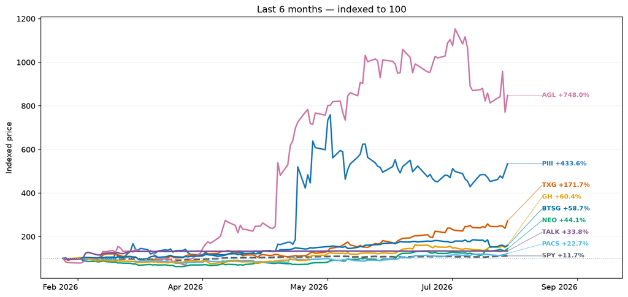

### Last 12 months

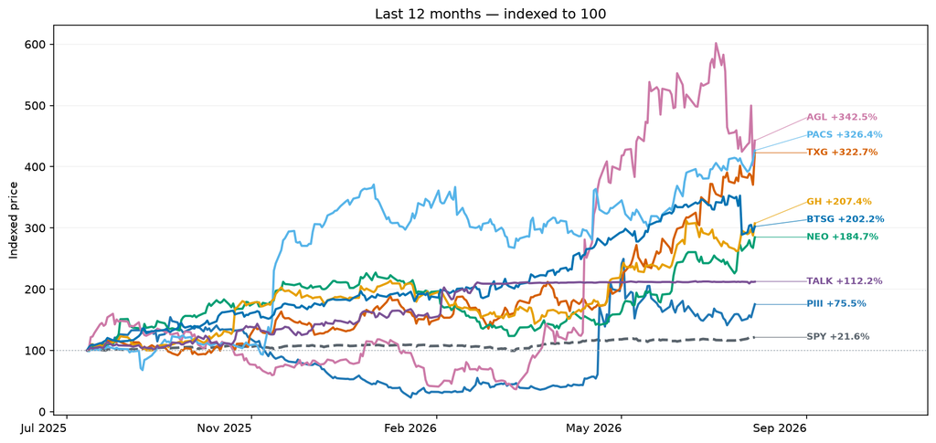

### Last 24 months

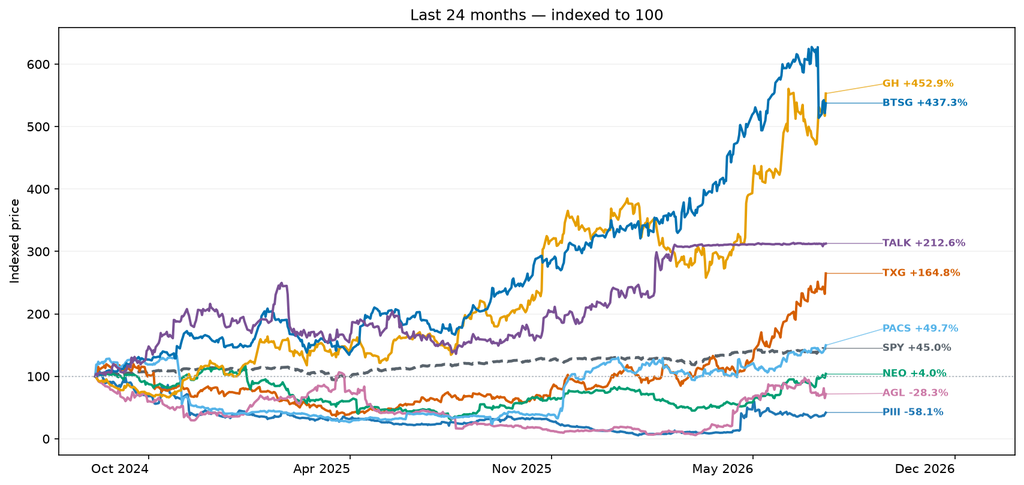

## Current Top Stocks

### Last 3 months

| Rank | Company | Ticker | Market cap | Return |
| --- | --- | --- | --- | --- |
| 1 | P3 Health | PIII | $32.7M | +226.4% |
| 2 | 10x Genomics | TXG | $6.1B | +140.9% |
| 3 | NeoGenomics | NEO | $2.1B | +84.9% |
| 4 | Agilon Health | AGL | $2.1B | +76.1% |
| 5 | Guardant Health | GH | $21.4B | +76.1% |

### Last 12 months

| Rank | Company | Ticker | Market cap | Return |
| --- | --- | --- | --- | --- |
| 1 | Agilon Health | AGL | $2.1B | +337.3% |
| 2 | PACS Group | PACS | $7.3B | +334.8% |
| 3 | 10x Genomics | TXG | $6.1B | +323.4% |
| 4 | Guardant Health | GH | $21.4B | +210.7% |
| 5 | BrightSpring Health Services | BTSG | $12.4B | +200.4% |

### Last 24 months

| Rank | Company | Ticker | Market cap | Return |
| --- | --- | --- | --- | --- |
| 1 | Guardant Health | GH | $21.4B | +481.0% |
| 2 | BrightSpring Health Services | BTSG | $12.4B | +441.0% |
| 3 | Talkspace | TALK | $874.4M | +208.9% |
| 4 | Natera | NTRA | $39.4B | +181.1% |
| 5 | Clover Health | CLOV | $2.2B | +155.9% |

## Companies by Subcategory

### PayersLast 3m: +8.3%

| Company | Ticker | Market cap | 3m Return | 12m Return | 24m Return |
| --- | --- | --- | --- | --- | --- |
| UnitedHealth | UNH | $380.1B | +7.1% | +62.3% | -27.1% |
| CVS Health | CVS | $135.1B | +5.7% | +46.0% | +67.6% |
| Humana | HUM | $43.7B | +40.0% | +44.4% | +9.7% |
| Oscar Health | OSCR | $9.4B | +30.9% | +80.5% | +54.6% |
| Molina Healthcare | MOH | $10.2B | +5.7% | +25.2% | -41.9% |
| Cigna | CI | $73.7B | -1.9% | +2.8% | -16.0% |
| Elevance | ELV | $81.5B | +4.3% | +34.1% | -25.9% |
| Clover Health | CLOV | $2.2B | +52.6% | +118.3% | +155.9% |
| Centene | CNC | $30.7B | +17.5% | +157.0% | -13.5% |
| Alignment Health | ALHC | $3.1B | -19.9% | -1.0% | +66.7% |

### Health System ProvidersLast 3m: +3.2%

| Company | Ticker | Market cap | 3m Return | 12m Return | 24m Return |
| --- | --- | --- | --- | --- | --- |
| HCA Healthcare | HCA | $87.2B | -5.0% | +8.3% | +14.5% |
| Tenet Health | THC | $20.5B | +37.7% | +58.3% | +74.7% |
| Universal Health Services | UHS | $10.2B | +2.1% | +0.7% | -19.4% |
| Community Health Systems | CYH | $417.4M | +7.5% | +20.5% | -38.0% |
| Ardent Health Partners | ARDT | $1.5B | +14.2% | -2.9% | -26.2% |

### Inpatient Non-Acute ProvidersLast 3m: +21.0%

| Company | Ticker | Market cap | 3m Return | 12m Return | 24m Return |
| --- | --- | --- | --- | --- | --- |
| The Ensign Group | ENSG | $10.4B | +6.7% | +13.9% | +29.5% |
| Acadia Healthcare | ACHC | $2.8B | +25.2% | +63.9% | -56.0% |
| Encompass Health | EHC | $11.0B | +18.0% | +6.5% | +46.1% |
| PACS Group | PACS | $7.3B | +44.2% | +334.8% | +47.9% |

### Health Care Real EstateLast 3m: +8.3%

| Company | Ticker | Market cap | 3m Return | 12m Return | 24m Return |
| --- | --- | --- | --- | --- | --- |
| Healthpeak properties | DOC | $15.1B | +9.0% | +26.2% | -1.0% |
| Ventas, Inc | VTR | $48.0B | +7.0% | +36.2% | +57.3% |
| Medical Properties Trust | MPT | $2.8B | -9.1% | — | — |
| National Health Investors | NHI | $3.7B | +0.1% | +0.5% | +0.7% |
| Omega Healthcare Investors | OHI | $15.1B | +2.7% | +21.3% | +27.4% |
| Welltower | WELL | $166.9B | +10.4% | +41.0% | +101.8% |
| CareTrust REIT | CTRE | $9.6B | -0.9% | +25.3% | +48.1% |
| Sabra Health Care REIT | SBRA | $5.3B | +1.4% | +12.4% | +26.1% |

### Value-Based CareLast 3m: +19.4%

| Company | Ticker | Market cap | 3m Return | 12m Return | 24m Return |
| --- | --- | --- | --- | --- | --- |
| Privia Health Group | PRVA | $3.0B | -2.6% | +9.1% | +17.7% |
| Astrana Health | ASTH | $1.8B | -9.0% | +27.4% | -25.4% |
| Agilon Health | AGL | $2.1B | +76.1% | +337.3% | -30.8% |
| Evolent Health | EVH | $347.6M | -5.5% | -56.1% | -85.0% |
| P3 Health | PIII | $32.7M | +226.4% | +72.8% | -61.8% |

### Outpatient and Home ProvidersLast 3m: +12.7%

| Company | Ticker | Market cap | 3m Return | 12m Return | 24m Return |
| --- | --- | --- | --- | --- | --- |
| Davita | DVA | $15.4B | -7.5% | +41.9% | +31.0% |
| Fresenius | FMS | $13.8B | +10.2% | +0.8% | +32.0% |
| Surgery Partners | SGRY | $2.0B | +7.5% | -34.3% | -47.8% |
| Option Care Health | OPCH | $3.4B | +16.0% | -15.6% | -20.3% |
| Lifestance Health | LFST | $4.0B | +40.8% | +148.1% | +93.6% |
| Chemed (Vitas) | CHE | $7.1B | +30.3% | +27.0% | -4.7% |
| Addus HomeCare | ADUS | $2.1B | +20.2% | +8.6% | -4.0% |
| Pennant Group | PNTG | $1.3B | +8.6% | +50.0% | +28.8% |
| US Physical Therapy | USPH | $1.2B | +35.0% | -8.7% | -9.4% |
| BrightSpring Health Services | BTSG | $12.4B | +13.9% | +200.4% | +441.0% |
| Aveanna Healthcare | AVAH | $2.0B | +40.8% | +54.6% | +101.5% |

### Digital Health, Specialty, BenefitsLast 3m: +22.5%

| Company | Ticker | Market cap | 3m Return | 12m Return | 24m Return |
| --- | --- | --- | --- | --- | --- |
| Teladoc | TDOC | $1.2B | -1.7% | +2.4% | -0.3% |
| Amwell | AMWL | $179.6M | +69.6% | +85.7% | +60.2% |
| Talkspace | TALK | $874.4M | +0.6% | +108.8% | +208.9% |
| Hims & Hers | HIMS | $6.4B | +11.7% | -39.2% | +97.9% |
| LifeMD | LFMD | $169.3M | -25.5% | -47.8% | -34.4% |
| Omada Health | OMDA | $1.2B | +59.7% | +24.4% | — |
| GoodRx | GDRX | $1.0B | +26.0% | +6.1% | -49.0% |
| Progyny | PGNY | $2.5B | +18.5% | +23.0% | +30.0% |
| Concentra Group | CON | $4.0B | +41.0% | +57.5% | +48.5% |
| HealthEquity | HQY | $8.8B | +23.3% | +12.4% | +47.0% |

### Health IT and DataLast 3m: -13.9%

| Company | Ticker | Market cap | 3m Return | 12m Return | 24m Return |
| --- | --- | --- | --- | --- | --- |
| Oracle-Cerner | ORCL | $374.1B | -25.0% | -41.2% | +11.3% |
| Veradigm | MDRX | n/a | +7.6% | +1.1% | -47.3% |
| Waystar | WAY | $4.0B | +13.3% | -30.0% | -1.1% |
| Solventum | SOLV | $13.6B | +13.1% | +13.1% | +37.0% |
| Phreesia | PHR | $663.2M | +23.0% | -53.7% | -45.9% |
| Consensus Cloud Solutions | CCSI | $669.7M | +3.4% | +47.4% | +76.8% |
| Definitive Healthcare | DH | $85.5M | -25.1% | -81.5% | -81.7% |
| Iqvia | IQV | $38.7B | +33.6% | +32.7% | +0.5% |
| Health Catalyst | HCAT | $154.4M | +13.8% | -38.9% | -74.0% |
| Doximity | DOCS | $3.8B | +5.5% | -58.8% | -23.0% |
| Veeva Systems | VEEV | $33.1B | +38.6% | -18.3% | +23.3% |
| Omnicell | OMCL | $1.7B | -16.0% | +19.4% | -9.9% |

### Pharma DistributionLast 3m: +22.0%

| Company | Ticker | Market cap | 3m Return | 12m Return | 24m Return |
| --- | --- | --- | --- | --- | --- |
| McKesson | MCK | $97.2B | +18.1% | +30.1% | +60.7% |
| Cardinal Health | CAH | $54.7B | +28.7% | +50.2% | +134.8% |
| Cencora | COR | $59.6B | +22.7% | +12.4% | +34.8% |
| Accendra Health | AHCO | $912.9M | -49.6% | -38.1% | -39.6% |
| Henry Schein | HSIC | $10.2B | +24.4% | +33.7% | +27.8% |

### Precision DiagnosticsLast 3m: +45.6%

| Company | Ticker | Market cap | 3m Return | 12m Return | 24m Return |
| --- | --- | --- | --- | --- | --- |
| Natera | NTRA | $39.4B | +65.8% | +112.0% | +181.1% |
| NeoGenomics | NEO | $2.1B | +84.9% | +185.7% | +0.1% |
| BillionToOne | BLLN | $6.5B | +0.5% | — | — |
| Guardant Health | GH | $21.4B | +76.1% | +210.7% | +481.0% |
| Tempus AI | TEM | $8.5B | +4.4% | -14.5% | +34.3% |
| Illumina | ILMN | $30.7B | +32.5% | +98.8% | +52.1% |
| 10x Genomics | TXG | $6.1B | +140.9% | +323.4% | +154.7% |
| PacBio | PACB | $447.3M | -16.0% | -12.2% | -25.5% |
| QuidelOrtho | QDEL | $1.2B | +13.8% | -48.6% | -70.5% |
| Quest Diagnostics | DGX | $25.8B | +27.2% | +34.7% | +59.6% |
| Labcorp Holdings | LH | $25.3B | +25.6% | +20.1% | +40.9% |
| Certara | CERT | $1.2B | +30.0% | -25.0% | -34.5% |

## Upcoming Earnings

### Health Care Real Estate

| Company | Ticker | Date | Market cap | 3m Return | 12m Return |
| --- | --- | --- | --- | --- | --- |
| National Health Investors | NHI | August 11, 2026 | $3.7B | +0.1% | +0.5% |
| Medical Properties Trust | MPT | August 10, 2026 | $2.8B | -9.1% | — |

### Outpatient and Home Providers

| Company | Ticker | Date | Market cap | 3m Return | 12m Return |
| --- | --- | --- | --- | --- | --- |
| Aveanna Healthcare | AVAH | August 13, 2026 | $2.0B | +40.8% | +54.6% |
| Surgery Partners | SGRY | August 10, 2026 | $2.0B | +7.5% | -34.3% |

### Digital Health, Specialty, Benefits

| Company | Ticker | Date | Market cap | 3m Return | 12m Return |
| --- | --- | --- | --- | --- | --- |
| Hims & Hers | HIMS | August 10, 2026 | $6.4B | +11.7% | -39.2% |

### Health IT and Data

| Company | Ticker | Date | Market cap | 3m Return | 12m Return |
| --- | --- | --- | --- | --- | --- |
| Definitive Healthcare | DH | August 10, 2026 | $85.5M | -25.1% | -81.5% |

### Pharma Distribution

| Company | Ticker | Date | Market cap | 3m Return | 12m Return |
| --- | --- | --- | --- | --- | --- |
| Cardinal Health | CAH | August 11, 2026 | $54.7B | +28.7% | +50.2% |

## Recent Earnings Highlights — 3m Ret

Companies covered in this section:

- CVS Health (CVS)
- McKesson (MCK)
- Cencora (COR)
- Natera (NTRA)
- Davita (DVA)
- Healthpeak properties (DOC)
- Fresenius (FMS)
- Solventum (SOLV)
- Encompass Health (EHC)
- Henry Schein (HSIC)
- CareTrust REIT (CTRE)
- Oscar Health (OSCR)
- PACS Group (PACS)
- BillionToOne (BLLN)
- 10x Genomics (TXG)
- Sabra Health Care REIT (SBRA)
- Lifestance Health (LFST)
- Concentra Group (CON)
- Doximity (DOCS)
- Privia Health Group (PRVA)
- Progyny (PGNY)
- Clover Health (CLOV)
- Addus HomeCare (ADUS)
- Agilon Health (AGL)
- Ardent Health Partners (ARDT)
- Pennant Group (PNTG)
- QuidelOrtho (QDEL)
- Certara (CERT)
- Omada Health (OMDA)
- US Physical Therapy (USPH)
- GoodRx (GDRX)
- Consensus Cloud Solutions (CCSI)
- PacBio (PACB)
- Evolent Health (EVH)
- Amwell (AMWL)
- Health Catalyst (HCAT)

### CVS Health (CVS) +5.7%

**Reported:** August 5, 2026 · [Google Finance earnings page](https://www.google.com/finance/quote/CVS:NYSE?tab=earnings&hl=en)

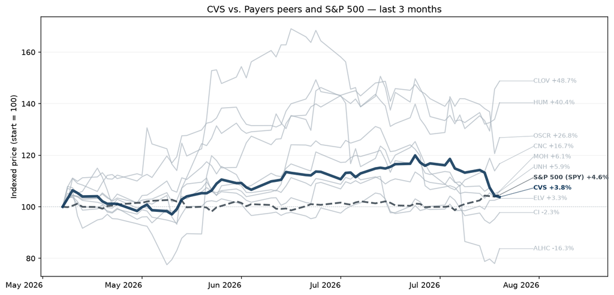

#### At a Glance

- **CVS Health Beats Second-Quarter Estimates:** CVS Health reported a strong bottom-line and top-line beat for the second quarter of 2026, posting a Reported Adjusted EPS of $2.31 against the estimated 1.851, and a Reported Revenue of $105.46 billion, which significantly surpassed the estimated $100.09 billion.
- **Medical Benefit Ratio Improves Meaningfully:** Aetna's medical benefit ratio (MBR), a critical industry KPI representing total medical expenses paid relative to premiums, improved to 87.4% from 89.9% in the prior-year quarter, driving higher segment profitability despite ongoing elevated medical costs.
- **Guidance Raised Amid Headwind Warnings:** Management raised its full-year 2026 Adjusted EPS guidance range to $7.90–$8.10 and operational cash flow to at least $11.5 billion, while simultaneously cautioning investors about potential 2027 headwinds in the Health Services segment stemming from 340B program dynamics.
- **Strategic Collaboration Expands GLP-1 Access:** CVS Health announced a new collaboration with Eli Lilly to expand weight management offerings, allowing patients to view pricing options for GLP-1 medications inside the CVS app with potential same-day pickup by the fourth quarter.
- **Shares Decline on Forward Outlook:** Despite delivering a strong beat-and-raise quarter, CVS Health shares fell between 6% and 9% post-earnings as investors reacted to management's conservative second-half growth implications and early conservative expectations for 2027.

### McKesson (MCK) +18.1%

**Reported:** August 5, 2026 · [Google Finance earnings page](https://www.google.com/finance/quote/MCK:NYSE?tab=earnings&hl=en)

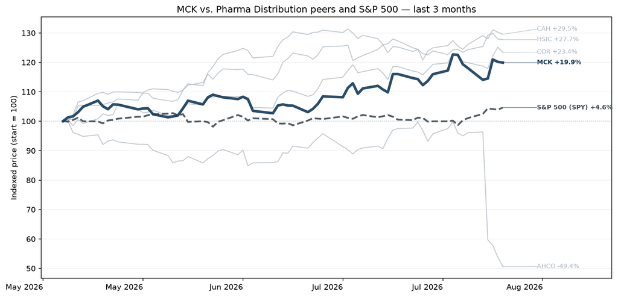

#### Earnings Call Summary

McKesson reported strong Q1 2027 revenues of $105.4 billion (+8% YoY) and adjusted EPS of $9.93 (+20% YoY), exceeding expectations. Driven by double-digit operating profit growth across three segments, management raised its full-year adjusted EPS guidance range to $44.20–$45.00, up from the prior outlook of $43.80–$44.60.

#### Key Moments from the Call

- **11m 26s — Medical-Surgical Separation and Wellverse Branding:** Management advanced its plan to separate the Medical-Surgical business, announcing its new market brand, Wellverse, set to formally debut in January 2027. Separation readiness was underscored by a completed 13% minority investment from Apollo Funds and a new $2.25 billion Term Loan B structure.
- **21m 13s — Robust Growth in GLP-1 Distribution Platforms:** GLP-1 pharmaceutical revenues jumped 24% year-over-year and 13% sequentially to reach $15 billion for the quarter. This expansion reflects sustained market demand across both cash-pay and covered segments, alongside high-efficiency prior authorization systems delivering determinations quickly.
- **27m 8s — Full-Year Adjusted EPS Guidance Increase:** McKesson raised its fiscal 2027 adjusted EPS outlook to $44.20–$45.00, implying 15%–17% core operational growth. This exceeds their long-term growth target of 13%–16%, fueled by strong Q1 outperformance, robust underlying specialty volumes, and steady operational momentum across its primary segments.
- **45m 50s — WAC Reductions and Fee-For-Service Stability:** Executives reassured investors that wholesale acquisition cost reductions implemented in January 2026 primarily impact top-line revenue metrics without hurting profitability. Because over 95% of branded contracts utilize fee-for-service frameworks, gross margins expanded despite falling list prices.

### Cencora (COR) +22.7%

**Reported:** August 5, 2026 · [Google Finance earnings page](https://www.google.com/finance/quote/COR:NYSE?tab=earnings&hl=en)

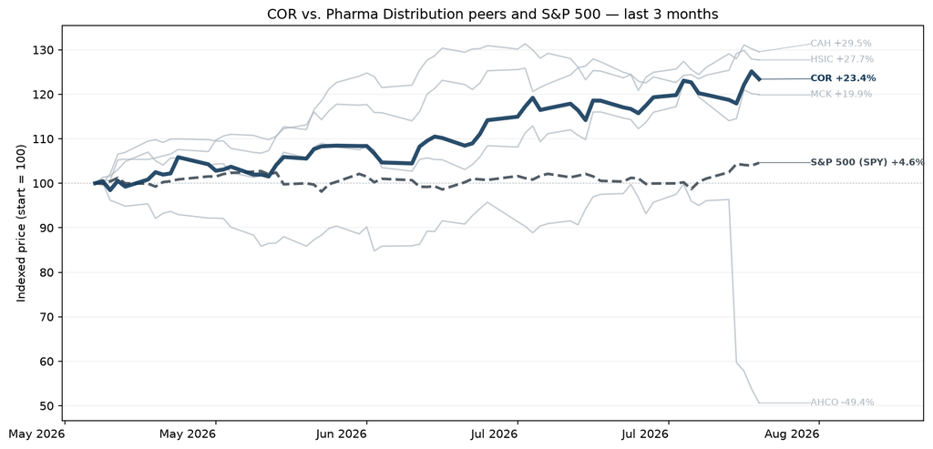

#### Earnings Call Summary

Cencora delivered 12% EPS growth in Q3 fiscal 2026, driven by execution across the firm and investments in its specialty positioning. Backed by $1 billion in opportunistic share repurchases, the company raised its full-year fiscal 2026 EPS guidance range to $17.75-$17.95, reflecting strong performance confidence.

#### At a Glance

- **Cencora Misses EPS, Beats Revenue:** Cencora reported a top-line revenue of $84.75 billion, beating expectations of $84.15 billion, while its reported adjusted EPS of $3.94 fell short of the estimated $4.35.
- **Margin Expansion Drives Profit Growth:** Cencora's adjusted gross margin expanded by 61 basis points to 4.16%, heavily supported by the successful integration of its OneOncology acquisition and strong specialty pharmaceutical distribution mix.
- **Full Year EPS Guidance Lifted:** Management raised its full-year fiscal 2026 adjusted EPS guidance to a range of $17.75 to $17.95, while maintaining its annual revenue growth projection of 4% to 6%.
- **U.S. Healthcare Segments Post Gains:** The U.S. Healthcare Solutions segment saw revenue increase by 5% to $74.9 billion, driven by robust demand for expensive specialty medications and a $2.3 billion year-over-year jump in GLP-1 sales.
- **International Healthcare Solutions Segment Rebounds:** Reversing prior sluggishness, international revenue grew 6% to $7.7 billion, propelled by a strong operational recovery in European distribution and global specialty logistics.
- **Aggressive Capital Deployment Through Repurchases:** Cencora aggressively deployed capital by executing $1 billion in opportunistic share repurchases during the quarter, optimizing its outstanding share count to boost long-term value.

#### Key Moments from the Call

- **1m 48s — Fiscal 2026 EPS Guidance Raised:** Cencora increased its full-year fiscal 2026 adjusted EPS guidance to a range of $17.75-$17.95, signaling strong business momentum and execution confidence to the market.
- **9m 29s — Massive Share Repurchases Executed:** The company deployed $1 billion toward opportunistic share repurchases in the quarter, reducing diluted share counts and contributing to the double-digit adjusted EPS growth.
- **13m 26s — OneOncology and MSO Platforms Outperform:** The recently acquired OneOncology platform, alongside RCA, performed ahead of management's expectations, helping drive a 16% operating income increase in the U.S. Healthcare segment.
- **19m 50s — Fiscal 2027 Headwinds Outlined:** Management provided early modeling insights for fiscal 2027, projecting a potential $0.35 net EPS headwind from the pending merger of MWI Animal Health with Covetrus.

### Natera (NTRA) +65.8%

**Reported:** August 6, 2026 · [Google Finance earnings page](https://www.google.com/finance/quote/NTRA:NASDAQ?tab=earnings&hl=en)

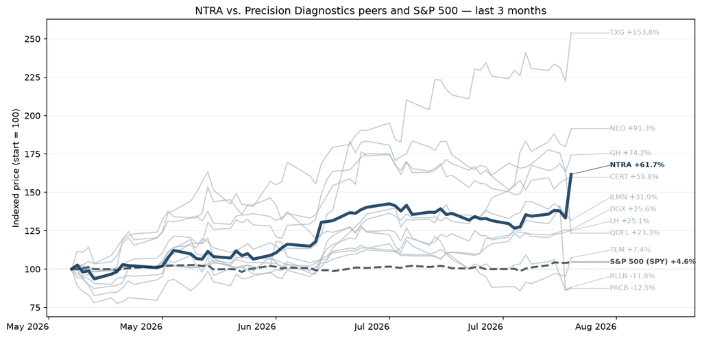

#### Earnings Call Summary

Natera processed over 1.04 million total tests in Q2 2026, setting a company record. Oncology clinical MRD units reached 283,000, representing 56% year-over-year growth and a record sequential increase of 34,000 units. Colorectal and breast cancers remain the largest indications, with strong contribution from other tumor types.

#### At a Glance

- **Natera Outperforms on Top and Bottom Lines:** Natera reported a Reported Adjusted EPS of -$0.47, beating the Estimated Adjusted EPS of -$0.534, while Reported Revenue of $752,750,000 exceeded the consensus estimate of $661,293,160.
- **Record Test Volumes Fuel Expansion:** The company processed approximately 1.044 million total tests in the quarter, marking a 22.4% year-over-year increase and establishing its second consecutive quarter above the 1 million unit milestone.
- **Full-Year Revenue Guidance Raised Substantially:** Natera raised its full-year 2026 revenue guidance by $100 million at the midpoint to a new range of $2.85 billion to $2.91 billion.
- **Oncology Segment Achieves Landmark Volume Growth:** Clinical molecular residual disease oncology units reached a record 283,000 tests, generating 56% year-over-year growth and the largest sequential increase in company history.
- **Strong Positive Market and Stock Response:** Driven by the substantial revenue beat and upgraded financial guidance, Natera's shares jumped over 16% in after-hours trading to surpass its previous 52-week high.
- **Key Regulatory and Reimbursement Milestones Cleared:** The quarter was highlighted by FDA companion-diagnostic approval for Signatera in bladder cancer, positive Japanese PMDA regulatory momentum, and expanded Medicare coverage for Prospera.

#### Key Moments from the Call

- **3m 47s — Massive Revenue Guidance Increase:** Natera completely reset its full-year 2026 revenue guidance, raising the midpoint by $100 million to $2.85B–$2.91B, representing 31% annual growth excluding true-ups. This substantial increase highlights excellent top-line momentum, driven by outperforming volumes in Signatera and resilient seasonally adjusted performance in Women's Health.
- **10m 0s — Unoptimized New Product COGS Impact:** While gross margin reached a strong 65%, sequential margin expansion was slightly tempered by a step-up in volumes for newly launched products like Fetal Focus and Latitude. Management reassured investors that while initial COGS are unoptimized, they plan to run dedicated margin-improvement projects over the next 12–18 months.
- **13m 46s — Expanded Medicare Transplant Coverage:** The final Medicare LCD for organ transplant surveillance published in July materially expanded covered testing frequencies relative to draft proposals. Effective August 30, this policy change creates an immediate monetization tailwind, boosting Prospera's volume and ASP outlook for the back half of 2026.
- **15m 28s — Signatera Regulatory and Guideline Milestones:** Signatera secured major global catalysts in Q2, becoming the first MRD test to gain U.S. FDA approval as a companion diagnostic and Japanese PMDA approval in colorectal cancer. Furthermore, it achieved an NCCN Category 1 recommendation in muscle-invasive bladder cancer, accelerating clinical adoption and favorable commercial coverage policies.

### Davita (DVA) -7.5%

**Reported:** August 4, 2026 · [Google Finance earnings page](https://www.google.com/finance/quote/DVA:NYSE?tab=earnings&hl=en)

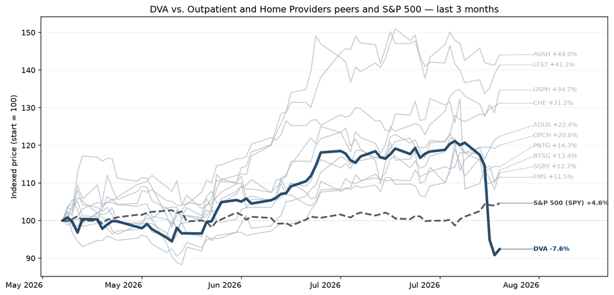

#### Earnings Call Summary

The 2027 CMS ESRD proposed rule tracks below cost trends but expands access by moving phosphate binders into the bundled payment. It reduced estimated drug spend by $500 million. DaVita supported the two-year TDAPA period limit, noting that ultimate 2027 financial impacts depend on final rule details later this year.

#### At a Glance

- **DaVita Tops EPS and Revenue Estimates:** DaVita Inc. reported second-quarter 2026 adjusted EPS of $4.02, beating the estimated $3.882, while its revenue of $3.554 billion also surpassed the estimated $3.494 billion.
- **Treatment Metrics Experience Mixed Performance:** U.S. dialysis treatment volume growth accelerated by 56 basis points year-over-year due to improved mortality, though revenue per treatment decreased by approximately $2 sequentially.
- **Full-Year Guidance Successfully Reaffirmed:** Management reconfirmed its full-year 2026 guidance, maintaining midpoints of $2.2 billion for adjusted operating income and $14.65 for adjusted EPS.
- **Commercial Mix Pressures Cloud Outlook:** The company expects a weaker mix as patients shift to government programs, leading to a projected $40 million headwind in 2026 and an expanded $70 million impact in 2027.
- **Stock Plummets Post-Earnings Despite Beat:** Despite surpassing top and bottom-line expectations, shares dropped over 7% in after-hours trading as investors focused on upcoming cost pressures and sequential declines in revenue per treatment.
- **Clinical Milestone Secured with New Dialyzers:** DaVita secured a full supply of newly FDA-approved expanded hemodialysis dialyzers following positive trial results, with plans to roll them out to facilities in upcoming quarters.

#### Key Moments from the Call

- **6m 36s — Expanded HD Dialyzer Deployment Acceleration:** DaVita secured a robust supply of NIPRO's new expanded HD dialyzers compatible with existing machines, enabling capital-efficient deployment. While financials are already within 2026 guidance, management noted a significant positive economic and mortality impact will not kick in or materialise until 2028.
- **9m 42s — Treatment Volume Outlook Nears Guidance Ceiling:** DaVita increased confidence in its volume trajectory, now expecting 2026 nominal treatment growth near the top end of its 25-50 basis points range. This acceleration is driven primarily by sustained improvements in patient mortality rather than new patient admissions, pleasing investors with solid clinical execution.
- **10m 55s — Commercial Mix Loss Impacts Revenue Per Treatment:** Revenue per treatment fell by $2 sequentially due to lower ACA exchange plan enrollment and commercial mix erosion. This shift creates a $40 million headwind in 2026 and an annualizing $70 million drag into 2027, explaining why second-half 2026 revenue per treatment growth will decelerate.
- **14m 36s — Integrated Care Performance and Phasing Details:** The Integrated Kidney Care segment delivered a stronger-than-expected $40 million in adjusted operating income due to revenue recognition timing. Management noted IKC continues to have a long runway for enterprise growth, and its timing will drive a major $50 million to $100 million sequential operating income step-up from Q3 to Q4.

### Healthpeak properties (DOC) +9.0%

**Reported:** August 5, 2026 · [Google Finance earnings page](https://www.google.com/finance/quote/DOC:NYSE?tab=earnings&hl=en)

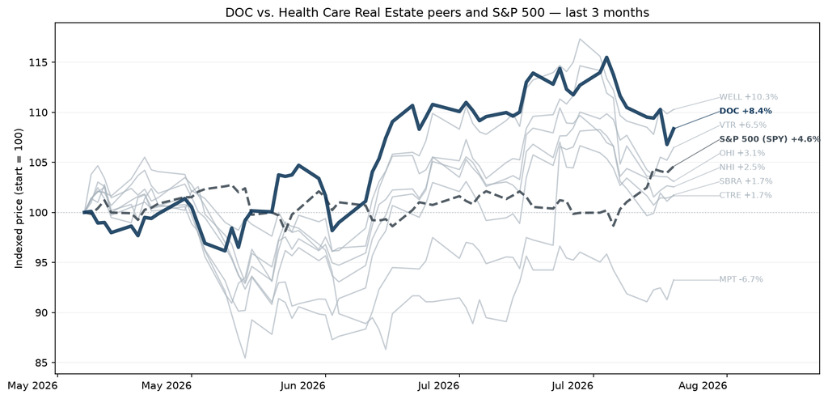

#### At a Glance

- **Healthpeak Beats Q2 Estimates Soundly:** Healthpeak Properties reported Q2 2026 adjusted EPS of $0.08 on revenue of $771.58 million, beating consensus expectations of $0.06 EPS and $725.16 million in revenue.
- **Strong Operational Gains Across Portfolio:** The company demonstrated sequential improvements in key real estate metrics, with outpatient medical occupancy rising 20 basis points to 90.7% and lab occupancy jumping 80 basis points to 78.5%.
- **Full-Year FFO Outlook Raised:** Fueled by accelerating same-store net operating income and leasing velocity, Healthpeak lifted its full-year 2026 adjusted FFO guidance range to $1.73 to $1.77 per share.
- **Brookfield Venture Injects Fresh Capital:** Healthpeak finalized a massive $2.1 billion strategic joint venture with Brookfield Asset Management for an 86-property outpatient portfolio, generating $1 billion in gross cash proceeds.
- **Senior Housing Consolidation Accelerates Expansion:** Following the Janus Living IPO transaction, Healthpeak shifted its senior housing strategy into hyperdrive, closing $1.8 billion in year-to-date acquisitions and logging 45% revenue growth for the segment.

#### Key Moments from the Call

- **6m 58s — Brookfield Joint Venture Deal Terms:** The Brookfield transaction features a trailing cash cap rate of 5.9%. Crucially, Healthpeak holds finite call rights after seven years to repurchase the non-controlling interest at a price delivering an unlevered 6.5% rate of return, positioning Healthpeak to capture upside in an in-the-money option.
- **10m 51s — Guidance Boost Sourced to Segment Strengths:** Management raised full-year adjusted FFO guidance to $1.73–$1.77 per share. This positive revision delights investors because it is supported by a 200 basis point increase in same-store NOI projections for both the reviving lab and booming senior housing segments.
- **18m 7s — Shift to Lab Consolidation Strategy:** CEO Scott Brinker noted that the life science sector is transitioning from a development game into an acquisition game. Armed with leverage below 5x, Healthpeak intends to act as a sector consolidator over the next 24 months, focusing on deeply discounted, core-market distressed assets.
- **32m 34s — Regional Divergence in Biotech Demand:** The Bay Area and San Diego show robust biotech demand, dramatically driving Torrey Pines leasing up to 97%. Conversely, Boston faces supply overhang. However, Boston showed signs of life in Q2 with market activity hitting 80% of full-year 2025 levels, reinforcing a localized sector inflection.

### Fresenius (FMS) +10.2%

**Reported:** August 4, 2026 · [Google Finance earnings page](https://www.google.com/finance/quote/FMS:NYSE?tab=earnings&hl=en)

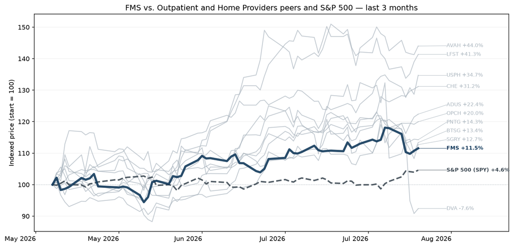

#### Earnings Call Summary

Fresenius Medical Care delivered a strong second quarter in 2026, accelerating operating income growth to 23% and continuing margin expansion, supported by the FME25+ transformation program which achieved EUR 67 million in sustainable savings. The initial EUR 1 billion share buyback program was completed early, and a second EUR 1 billion program has launched.

#### Key Moments from the Call

- **3m 44s — U.S. Patient Referral Execution Gap:** Investors will face disappointment over a 0.9% decline in U.S. same-market treatment growth, driven by internal operational failures in capturing patient referrals rather than overall market issues. This operational miss has led management to lower its full-year volume growth expectations to match Q2 levels, pushing potential volume recoveries into 2027.
- **16m 39s — Value-Based Care Profit Turnaround:** Investors will be pleased with the robust improvement in Value-Based Care, which swung from a EUR 9 million loss to EUR 18 million in operating income. The margin expansion of 500 basis points and improved full-year revenue outlook indicate that the company's contracting strategy and vertically integrated model are translating into sustainable profitability.
- **18m 46s — Accelerated Share Buyback Launch:** The fast execution of capital return initiatives will satisfy investors, as the company completed its initial EUR 1 billion share buyback ahead of schedule and instantly deployed a second EUR 1 billion program. This aggressive strategy underscores balance sheet confidence while keeping leverage at the lower end of the target corridor.
- **20m 36s — Favorable TDAPA Headwind Revision:** The upward revision of full-year TDAPA outlook will please shareholders, as anticipated net regulatory headwinds dropped from EUR 100 million down to EUR 50 million. Stronger performance in the first half provided an EUR 80 million year-over-year tailwind, mitigating some of the anticipated downside from reimbursement shifts coming in the second half.

### Solventum (SOLV) +13.1%

**Reported:** August 5, 2026 · [Google Finance earnings page](https://www.google.com/finance/quote/SOLV:NYSE?tab=earnings&hl=en)

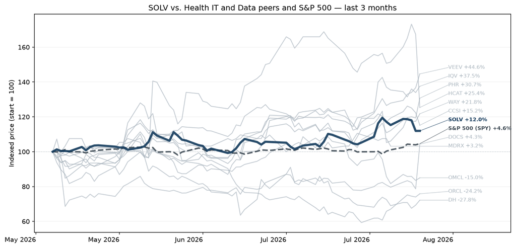

#### Earnings Call Summary

Solventum delivered a strong Q2 2026, exceeding top- and bottom-line expectations with reported revenue of $2.209B and EPS of $2.55, driven by healthy execution across all segments. Results included planned advanced orders of approximately $125 million ahead of the North America ERP cutover.

#### At a Glance

- **Solventum Tops EPS and Revenue Estimates:** Solventum reported a reported revenue of $2,209,000,000, surpassing the estimated $2,155,703,990, and posted a reported adjusted EPS of $2.55, which significantly outperformed the consensus forecast of $1.906.
- **Organic Growth Boosted Across Segments:** The company delivered organic sales growth of 9.5%, reflecting strong volume and product mix across all reportable segments, though normalized organic growth was closer to 4% after excluding advance ERP orders.
- **Solventum Raises Full-Year Guidance Considerably:** Management increased its full-year 2026 outlook, raising organic sales growth expectations to 2.5%–3.0%, free cash flow to $200M–$300M, and adjusted EPS to a range of $7.10–$7.20.
- **Health Information Systems Unit Separation:** Solventum announced its intent to separate its Health Information Systems business segment as part of a transformation strategy to sharpen its core focus as a dedicated MedTech company.
- **Tariff Refund Lifts Profitability Margins:** The company's adjusted operating income margin rose to 28.4%, receiving a notable temporary lift from a one-time $100 million IEEPA tariff refund benefit.
- **Positive Initial Market Reaction Sparked:** Following the substantial bottom-line earnings beat and the upbeat guidance adjustments, Solventum shares gained 2.9% in immediate after-market trading.

#### Key Moments from the Call

- **4m 29s — Health Information Systems Strategic Separation:** Solventum announced plans to separate its Health Information Systems business. This strategic shift will transition Solventum into a pure-play med tech company focused on MedSurg and Dental, while allowing HIS to better capture AI-driven autonomous coding advances independently or with a scaled partner.
- **16m 37s — Acera Integration Outperformance:** The recently acquired Acera business delivered outstanding 48% growth in the quarter, generating $32 million in sales with gross margins over 80%. This strong execution validates the company's tuck-in M&A playbook and provides investors with a high-margin, high-growth catalyst within Advanced Wound Care.
- **21m 39s — Substantial Guidance Increase:** Management raised full-year 2026 EPS guidance to $7.10–$7.20 from $6.40–$6.60 and bumped ex-SKU organic growth expectations. This positive revision, supported by strong first-half execution and a $100 million tariff refund benefit, signals accelerating progress toward achieving long-range targets earlier than planned.
- **43m 38s — ERP Advanced Orders Cadence Volatility:** Results included $125 million in advanced orders to mitigate ERP cutover risks, boosting organic growth by 630 basis points. Management explicitly warned analysts that this timing benefit will reverse in Q3, leading to an expected sales decline of -3% to -4% before recovering in Q4.

### Encompass Health (EHC) +18.0%

**Reported:** August 6, 2026 · [Google Finance earnings page](https://www.google.com/finance/quote/EHC:NYSE?tab=earnings&hl=en)

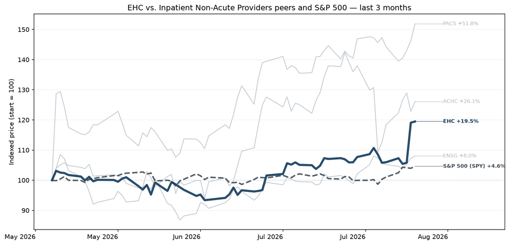

#### Earnings Call Summary

Encompass Health reported strong Q2 2026 results with revenue growth of 9.6% year-over-year to $1.597 billion, beating estimated revenue of $1.571 billion. Adjusted EBITDA increased 9.2% to $348 million, and adjusted EPS grew 10.7% to $1.55, exceeding the estimated EPS of $1.48, driven by volume growth and higher patient acuity.

#### At a Glance

- **Encompass Health Beats Earnings Estimates:** Encompass Health exceeded market expectations for the second quarter of 2026, delivering a reported adjusted EPS of $1.54 against a $1.48 estimate, alongside a reported revenue of $1.597 billion which topped the forecasted $1.571 billion.
- **Discharge Metrics Drive Volume Expansion:** The company achieved a 5.6% increase in total discharges for the quarter, balanced evenly with a 2.8% increase in same-store discharge growth and a 2.8% contribution from new-store discharge growth.
- **Full-Year Financial Guidance Raised:** Citing sustained operational momentum, management raised its full-year 2026 guidance, now projecting net operating revenue of $6.41 billion to $6.49 billion and adjusted EPS of $6.02 to $6.25.
- **Higher Patient Acuity Boosts Revenue:** Net patient revenue per discharge rose by 3.9%, largely driven by growth in medically complex categories like stroke and brain injury, which saw total volume increases of 7.9% and 8.0% respectively.
- **Positive Hospital Capacity and Openings:** Encompass Health expanded its footprint by opening three new hospitals and adding 54 beds during the first half of the year, with plans to add five more hospitals and over 100 beds before year-end.
- **Enhanced Capital Allocation Strategies:** The board approved a major expansion to its common stock repurchase program, boosting the aggregate authorization to $1 billion alongside a 10.5% increase in its quarterly dividend to $0.21 per share.

#### Key Moments from the Call

- **15m 11s — North Carolina CON Repeal Expansion Strategy:** The repeal of North Carolina's CON law opens up a large, underserved market. Encompass Health is moving quickly with a portfolio approach targeting 15 markets, which will likely accelerate long-term bed growth towards the high end of their 6-10 de novo annual range by 2029.
- **19m 49s — Full-Year 2026 Guidance Raised:** Encompass Health raised its full-year 2026 financial guidance across revenue, adjusted EBITDA, and adjusted EPS. This positive revision reflects strong first-half financial performance, solid volume growth, and higher patient acuity, which will please investors despite increased labor cost assumptions.
- **28m 44s — Successful Medicare Advantage Admit and Appeal Pilot:** Addressing persistent Medicare Advantage pre-authorization denials, the company's "admit and appeal" pilot achieved an 89% success rate across 144 adjudicated cases. Scaling this strategy will reassure investors of Encompass Health's ability to protect its volume and counter payer headwinds.
- **36m 17s — Career Ladders Drive Record Low Workforce Turnover:** Investments in clinical career ladders reduced nursing turnover to a 12-year low of ~19% and therapy turnover to a 5-year low of ~7%. This operational success directly lowered premium labor spend to 1.1% of total FTEs, improving P&L efficiency and supporting higher patient acuity capacity.

### Henry Schein (HSIC) +24.4%

**Reported:** August 4, 2026 · [Google Finance earnings page](https://www.google.com/finance/quote/HSIC:NASDAQ?tab=earnings&hl=en)

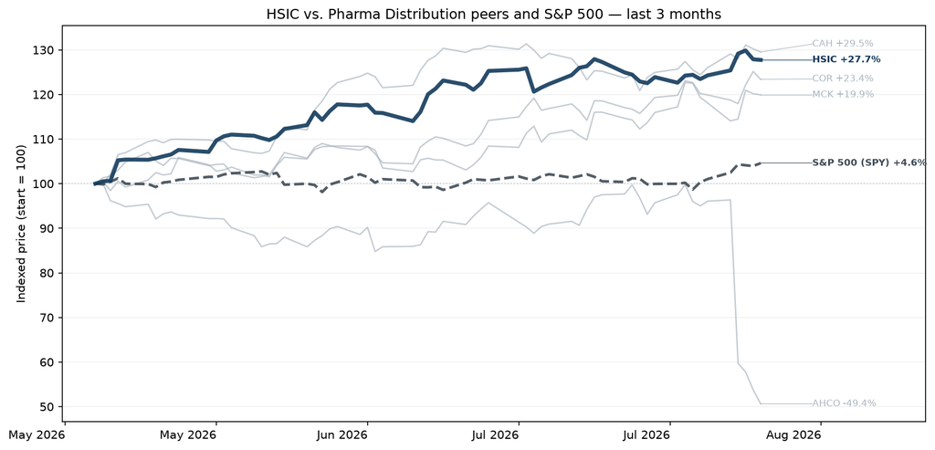

#### Earnings Call Summary

Henry Schein reported strong Q2 2026 sales and margin performance, with global sales increasing 6.7% to $3.5 billion, featuring internal local currency sales growth of 4.6%. Non-GAAP operating income grew 10.5% and non-GAAP EPS rose 15.5% to $1.27, driven by sustained business momentum and early benefits from value creation initiatives.

#### Key Moments from the Call

- **16m 3s — Global Business Outsourcing Benefits Looming:** The company completed its global outsourcing provider selection for finance and customer service, initiating phase I in the U.S. This initiative is expected to unlock labor cost efficiencies beginning in Q3 2026 and eventually yield more than half of the targeted $200 million G&A savings.
- **20m 58s — Consumables Growth Outpacing Market:** U.S. Dental Merchandise sales grew an impressive 8.3% (6.5% internal local currency). This clear outperformance and market share expansion pleased investors, as the company successfully converted episodic buyers into active accounts through targeted promotional strategies despite tougher prior-year comparisons.
- **25m 55s — Full-Year 2026 Guidance Raised:** Management raised full-year 2026 sales growth guidance to 4.5%-5.5% and non-GAAP EPS guidance to $5.29-$5.39. This revision highlights robust underlying commercial momentum and stable end-market demand, though the bottom-line flow-through is partially tempered by a reduction in forecasted non-operating remeasurement gains.
- **51m 45s — Management Structural Optimization:** CEO Fred Lowery announced structural changes to the executive committee, removing a management layer to flatten the organization and integrate the supply chain directly into distribution operations. This adjustment aims to increase decision-making velocity and operational consistency.

### CareTrust REIT (CTRE) -0.9%

**Reported:** August 7, 2026 · [Google Finance earnings page](https://www.google.com/finance/quote/CTRE:NYSE?tab=earnings&hl=en)

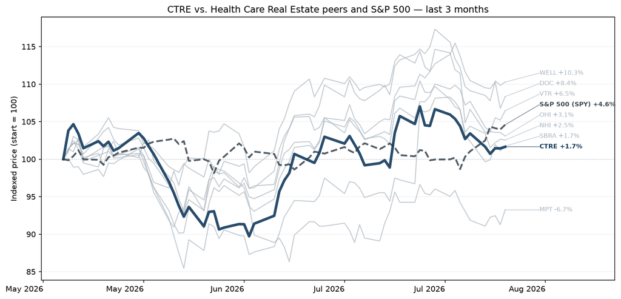

#### Earnings Call Summary

CareTrust REIT achieved a record investment quarter in Q2 2026, deploying approximately $900 million at a blended stabilized yield of 8.9%. Year-to-date investments have reached $1.5 billion, encompassing U.S. triple-net skilled nursing, U.S. senior housing, U.K. care homes, SHOP platforms, and real estate loans.

#### At a Glance

- **CareTrust Reports Mixed Quarterly Results:** CareTrust REIT reported a Reported Adjusted EPS of 0.38, missing the estimated 0.393, while its reported revenue of $161.35 million beat the estimate of $156.14 million.
- **Strong Core Real Estate KPIs:** The company recorded a 44% year-over-year surge in Normalized FFO to $119.7 million, with Normalized FFO per share expanding 19% to $0.51, matching consensus expectations.
- **Full Year Guidance Raised Significantly:** Management increased its full-year 2026 outlook, now projecting a normalized FFO per share range of $2.03 to $2.06 and a normalized FAD per share range of $2.01 to $2.04.
- **Record Capital Deployment Extends Pipeline:** CareTrust completed a record $900 million of investments during the quarter at an 8.9% blended stabilized yield, pushing year-to-date deployments to $1.5 billion.
- **Muted Immediate Market Stock Reaction:** The company's stock reacted quietly to the mixed metrics, finishing nearly flat at $41.16 as the solid core FFO and guidance increase balanced out bottom-line variances.

#### Key Moments from the Call

- **1m 48s — Record Capital Deployment Milestone:** The company posted its single largest non-M&A investment quarter ever, putting $900 million to work at a high 8.9% blended yield, proving its unique capacity to expand aggressively in the skilled nursing and care home sectors.
- **10m 32s — Raised Full-Year 2026 Guidance:** CareTrust increased its full-year outlook to reflect massive year-to-date deployment. Midpoint projections signal double-digit FFO and FAD per-share growth of 16.2% and 15.1% respectively, providing a highly positive surprise for investors.
- **11m 39s — Ultra-Low Leverage and High Liquidity:** Reporting a leverage ratio of just 1.0x EBITDA and $1.4 billion in available dry powder, the company reassured investors of its stellar balance sheet insulation against fluctuating interest rates and macroeconomic volatility.
- **23m 48s — Strategic Patience on SHOP Assets:** Management defended the lack of near-term SHOP deals by emphasizing disciplined risk-adjusted returns over chasing low-cap-rate transactions, signaling to investors that they will not sacrifice long-term value for immediate growth metrics.

### Oscar Health (OSCR) +30.9%

**Reported:** August 6, 2026 · [Google Finance earnings page](https://www.google.com/finance/quote/OSCR:NYSE?tab=earnings&hl=en)

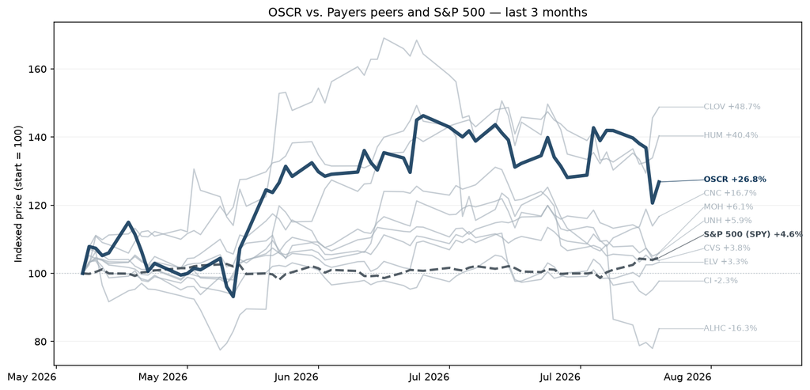

#### Earnings Call Summary

Oscar Health reported strong Q2 2026 results, with revenue up 70% year-over-year to $4.9 billion, driven by higher membership and rate increases. First-half results delivered record profitability, generating $1.1 billion in earnings from operations and $1 billion in net income, while second-quarter earnings from operations increased by $619 million year-over-year to $389 million.

#### At a Glance

- **Oscar Health Beats Earnings Estimates:** Oscar Health reported a Reported Adjusted EPS of 1.1, beating the Estimated Adjusted EPS of 0.38, while Reported Revenue reached 4,880,220,000 against the estimated 4,751,123,190.
- **Medical Loss Ratio Improves Sharply:** The company's core Medical Loss Ratio (MLR) collapsed by roughly 12 percentage points year-over-year to 79.2% for the second quarter, indicating significantly improved underwriting margins compared to past performance.
- **Full Year Operating Outlook Raised:** Management raised its full-year 2026 operational earnings guidance to a range of $500 million to $700 million, a major increase from its previous outlook of $250 million to $450 million.
- **Membership Base Surges Significantly:** Oscar Health reached 2.96 million effectuated members as of June 30, 2026, representing a robust 46% increase year-over-year.
- **Elevated Enrollment Churn Expected Ahead:** Management warned that membership churn could double to around 2% to 4% in the second half of 2026 due to accelerated CMS eligibility verification processes.
- **Record Efficiencies Drive Bottom Line:** The SG&A expense ratio reached a record low of 14.2%, down 450 basis points year-over-year, heavily supported by AI-driven automation and technology efficiencies.

#### Key Moments from the Call

- **10m 12s — Favorable Risk Adjustment and Morbidity:** The company recorded a $160 million favorable true-up from the final 2025 CMS risk adjustment report. Additionally, early 2026 market morbidity data from Wakely tracks favorable to pricing assumptions, pointing to potential tailwinds if these positive trends hold through the remainder of the year.
- **11m 3s — Elevated Outpatient Utilization Stability:** While inpatient, professional, and pharmacy utilization were favorable in the first half of the year, outpatient utilization was noted as elevated. However, management reassured investors that these trends remain stable, reasonable, and favorable to overall initial pricing expectations.
- **13m 16s — Full-Year 2026 Guidance Raise:** Oscar Health raised its full-year 2026 earnings from operations outlook by $250 million to a range of $500 million–$700 million, while improving full-year MLR expectations by 90 basis points at the midpoint to 81.5%–82.5%, highlighting strong first-half operating momentum and favorable market morbidity.
- **38m 14s — Second-Half Membership Churn Guidance:** Management forecasts an acceleration in membership churn during the second half of 2026, estimating monthly lapse rates will double from previous 1%–2% expectations. This is attributed to delayed CMS eligibility verification and program integrity processes, though financial impacts are already factored into full-year guidance.

### PACS Group (PACS) +44.2%

**Reported:** August 5, 2026 · [Google Finance earnings page](https://www.google.com/finance/quote/PACS:NYSE?tab=earnings&hl=en)

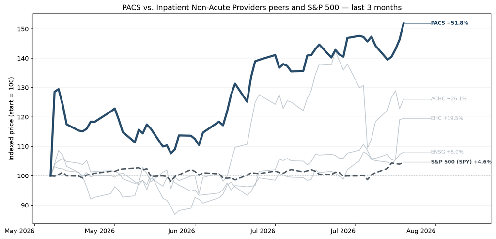

#### Earnings Call Summary

PACS Group reported strong Q2 2026 results, with revenue growing 9.1% year-over-year to $1.43 billion and net income increasing 50% to $76.4 million. Adjusted EBITDA grew 25% to $166.8 million, demonstrating meaningful margin expansion as facilities mature, occupancy climbs, and patient mix improves.

#### Key Moments from the Call

- **12m 32s — Strategic Expansion via Eduro Asset Acquisition:** The company announced a definitive agreement to acquire 34 skilled nursing facilities from Eduro Healthcare. Having closed on the first 20 facilities in Texas on August 1, management notes significant upside to transition these low-occupancy assets (mid-60%) into its higher-performing ramping and mature cohorts.
- **21m 38s — Strong Earnings Beat and Raised Guidance:** PACS Group significantly exceeded Q2 expectations with a reported EPS of $0.626 versus the $0.56 estimate, and revenue of $1.43 billion ahead of the $1.41 billion estimate. Backed by core portfolio momentum, management raised full-year 2026 revenue and adjusted EBITDA guidance ranges by $100 million and $35 million, respectively, pleasing investors.
- **38m 32s — Improving Labor Dynamics and Margin Expansion:** Contract labor in Q2 reached its lowest level in two years, signaling a continuing stabilization in the broader healthcare labor market. This reduction in high-cost agency staff and overtime, alongside robust same-store occupancy gains, is directly translating into meaningful operating leverage and margin expansion for the business.
- **42m 39s — Unquantified Reimbursement Upside Excluded from Guidance:** Management revealed that anticipated supplemental payments, including Ohio prior-year quality incentives and a California WQIP payment, have been completely excluded from the raised 2026 guidance due to timing and sizing uncertainty. Investors will view this conservative methodology as an embedded catalyst for financial upside in the back half of 2026.

**Reported:** August 5, 2026 · [Google Finance earnings page](https://www.google.com/finance/quote/BLLN:NASDAQ?tab=earnings&hl=en)

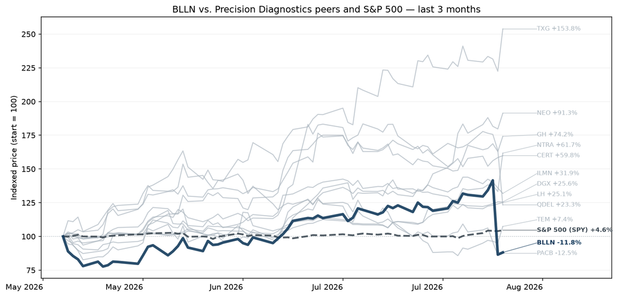

#### Earnings Call Summary

BillionToOne reported strong Q2 2026 results, with total revenue increasing 64% year-over-year to $109.4 million, driven by a 35% increase in test volumes to 196,000 and a 21% increase in ASP to $551. The company achieved GAAP operating income of $5.5 million (5% margin) and an adjusted EBITDA margin of 15%.

#### At a Glance

- **BillionToOne Beats EPS and Revenue Estimates:** BillionToOne Inc reported Q2 2026 adjusted EPS of $0.15, beating the estimated $0.09, and generated revenue of $109,448,000 against the estimated $108,520,000.
- **Strong Test Volume and ASP Growth:** The company's performance was driven by an industry KPI of approximately 196,000 tests delivered, representing 35% year-over-year growth, alongside a 21% increase in Overall Average Selling Price to $551 per test.
- **Full-Year 2026 Guidance Reiterate:** BillionToOne reiterated its full-year 2026 revenue guidance of $450 million to $465 million, which represents an expected growth rate of 48% to 52% over 2025 results.
- **Oncology Segment Achieves Explosive Scale:** While the core prenatal clinical testing segment brought in $95.8 million, oncology segment revenue surged by 176% year-over-year to $13.7 million, validating the company's expansion into cancer diagnostics.
- **Stock Plunges Despite Earnings Beat:** Despite beating top and bottom-line expectations, BillionToOne shares plummeted over 38% following the release, as investors reacted with disappointment to the unchanged full-year guidance and over $10 million in claims temporarily held up by payers.
- **Expanding Commercial Infrastructure and Partnerships:** Management accelerated commercial investment by adding roughly 70 sales representatives in the first half of 2026 and reached an infrastructure milestone with a rapid platform launch integration on Epic Aura.

#### Key Moments from the Call

- **9m 21s — MolDX Coverage Timeline Secured:** A peer-reviewed study validating Northstar Response for immunotherapy monitoring was published in June. This clinical evidence supports the pursuit of MolDX Medicare coverage for the assay, which represents two-thirds of oncology volume and remains on track for approval by the end of 2026.
- **13m 29s — Epic Aura Integration Milestone:** BillionToOne successfully launched on the Epic Aura platform in under five months, completing its first health system integration in just two weeks. This removes a critical IT barrier, enabling seamless electronic medical record (EMR) test ordering and positioning the company for accelerated health system adoption entering 2027.
- **13m 29s — Accelerated Sales Hiring:** The company hired 70 sales representatives in the first half of 2026, moving ahead of its initial plan due to a strong talent pipeline. While the rapid expansion temporarily diluted short-term sales productivity, it is expected to fuel significant growth late this year as reps become fully productive.
- **40m 54s — Insulated From Payer Friction:** Unlike competitors facing increased payer friction and unbundling issues in carrier screening, BillionToOne remains unaffected. The company intentionally utilizes proprietary PLA codes effective since January 2025, rather than stacked billing codes, shielding its prenatal business from national payer restrictions.

### 10x Genomics (TXG) +140.9%

**Reported:** August 6, 2026 · [Google Finance earnings page](https://www.google.com/finance/quote/TXG:NASDAQ?tab=earnings&hl=en)

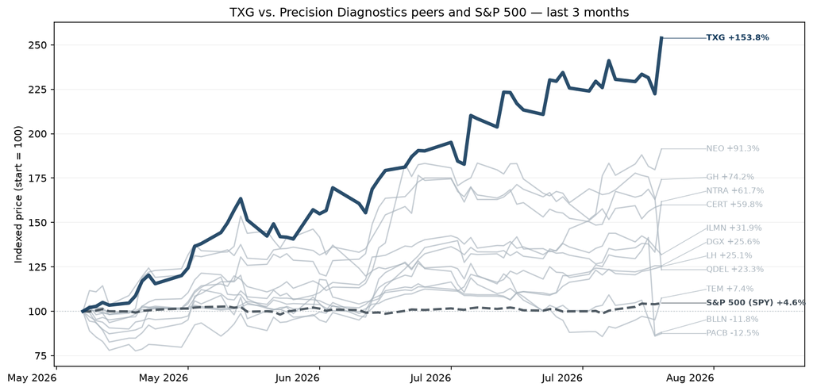

#### Earnings Call Summary

10x Genomics reported Q2 2026 revenue of $151 million, which included $1.6 million from a settlement with Takara. Excluding this settlement, Q2 revenue was $149 million, representing a 3% year-over-year growth driven by continuous momentum across key business segments.

#### Key Moments from the Call

- **20m 2s — Atera Revenue Impact and Production Outlook:** Atera instrument orders have significantly outpaced the company's full-year shipment target of approximately 40 units. Due to manufacturing and production capacity constraints, management left its shipment outlook unchanged for 2026, keeping a back-half weighted trajectory mostly targeted at Q4.
- **21m 9s — Quarterly Cadence and Sequential Revenue Step-down:** Management projected a modest sequential revenue step-down in Q3 2026 due to anticipated spatial transition dynamics, as customers temporarily moderate current spatial product and consumable purchases ahead of receiving Atera. A significant step-up is forecasted for Q4 as Atera shipments ramp up.
- **38m 32s — Chromium Consumable Volume Growth and Centralization:** Chromium consumable reaction volume grew robustly, driven by the adoption of Flex Apex for large-scale perturbation screening. This scalability has caused sample processing to centralize into larger core labs, decreasing the immediate need to place new Chromium instruments at individual labs.
- **48m 9s — Macro Academic Funding Hurdles Persist:** The academic end-market macro environment remains tenuous. While high-level funding and grant approvals are occurring, multi-year allocation rules, staffing shortages, and strict review administrative constraints continue to delay these funds from translating into immediate purchasing activity or revenue.

### Sabra Health Care REIT (SBRA) +1.4%

**Reported:** August 4, 2026 · [Google Finance earnings page](https://www.google.com/finance/quote/SBRA:NASDAQ?tab=earnings&hl=en)

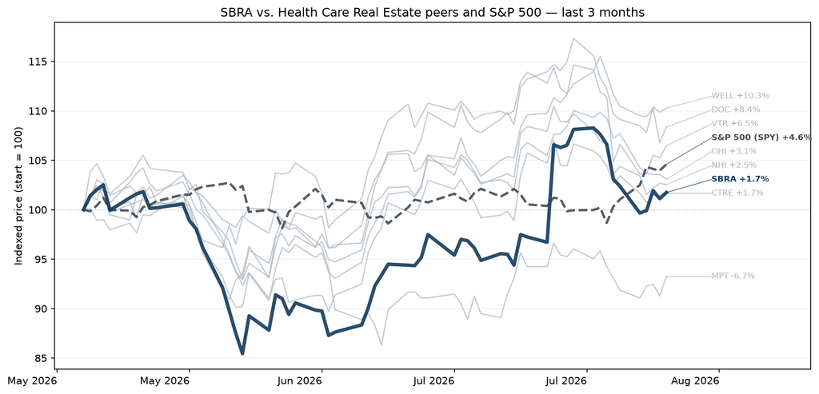

#### Earnings Call Summary

Sabra Health Care REIT closed $600 million in investments, with an additional $100 million in SHOP investments expected before year-end. Total year-to-date investments reached approximately $599 million at a 7.5% cash yield, while the forward-looking pipeline exceeds $1 billion, predominantly focused on SHOP opportunities to continue growing senior housing exposure.

#### At a Glance

- **Sabra Misses EPS but Beats Revenue:** Sabra Health Care REIT reported a Q2 Adjusted EPS of -$0.10, missing the estimated profit of $0.167, while total revenue came in at $238,090,000, beating the estimated $219,459,600.
- **Strong Same-Store Senior Housing Performance:** The company's Senior Housing Managed portfolio (SHOP) delivered robust growth, with same-store cash NOI increasing 13.7% year-over-year and same-store occupancy improving by 170 basis points to 88.2%.
- **Full-Year 2026 Guidance Reaffirmed:** Management reiterated its previously upgraded full-year 2026 guidance, expecting normalized FFO per share growth of approximately 7% and normalized AFFO per share growth of roughly 8% at the midpoint.
- **Loan Loss Provision Weights on Earnings:** Headline GAAP net income was heavily impacted by a $102.4 million non-cash provision for loan losses and other reserves resulting from the discounted payoff of the RCA mortgage loan.
- **Significant Sequential Leverage Position Improvement:** Sabra's Net Debt to Adjusted EBITDA improved to 4.61x down from 5.04x at the end of March, placing the company comfortably below its historical leverage target threshold.

#### Key Moments from the Call

- **7m 37s — Avamere Rent Reset and Transition Step-Up:** Sabra reset its Avamere lease rent to $48 million retroactively, adding $3.2 million to the quarter's revenue. Management expects this rent to step up to $53 million post-transition later this year, providing a significant annualized organic revenue lift heading into 2027.
- **11m 49s — Improved Balance Sheet and Reduced Leverage:** Sabra's net debt to adjusted EBITDA improved significantly to 4.61x from 5.04x in the prior quarter. This drop puts the company comfortably below its 5.0x target, driven by the payoff of the RCA Mortgage Loan and robust core earnings growth.
- **15m 46s — SHOP Value-Add Pipeline Expansion:** Management detailed a targeted value-add pipeline involving six senior housing properties at ~80% occupancy. Acquired below replacement costs with existing operator relationships, these assets are projected to move from a 6% year-one yield to a 9% stabilized yield with mid-teens IRRs.
- **32m 11s — Sustainable High-Single Digit Growth Target:** Following an upward revision in July, management reaffirmed its 2026 earnings guidance, which projects 7% FFO and 8% AFFO growth at the midpoint. Leadership expressed confidence that benefits from recent acquisitions and structural SHOP expansion make these growth rates highly sustainable into 2027 and 2028.

### Lifestance Health (LFST) +40.8%

**Reported:** August 6, 2026 · [Google Finance earnings page](https://www.google.com/finance/quote/LFST:NASDAQ?tab=earnings&hl=en)

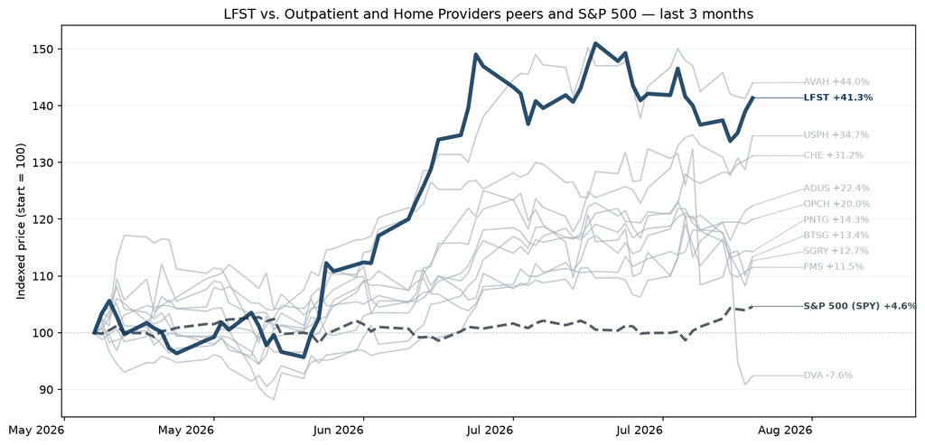

#### Earnings Call Summary

LifeStance Health reported exceptional Q2 2026 financial results with revenue growing 26% year-over-year to $435 million, beating expectations. The growth was driven by a 19% increase in visit volumes to 2.6 million and a 6% increase in total revenue per visit to $167.

#### At a Glance

- **LifeStance Beats Q2 Revenue Estimates:** LifeStance Health reported a Q2 2026 revenue of $435,354,000, outperforming the estimated $414,532,890, while its reported adjusted EPS of $0.06 was down from the estimated $0.082.
- **Clinician Expansion Drives Operational Volume:** The company's core KPIs excelled as total visit volumes rose 19% year-over-year to 2.6 million, fueled by expanding the total clinician base 11% to 8,542 and growing visits per clinician by 7%.
- **Full-Year 2026 Guidance Upgraded:** Management raised its full-year 2026 revenue guidance to a range of $1.685 billion to $1.725 billion, surpassing previous expectations due to strong year-to-date performance and durable payer contract rate increases.
- **EBITDA and Cash Generation Surge:** Adjusted EBITDA surged 94% year-over-year to $66 million, expanding the adjusted EBITDA margin by over 500 basis points to 15.2% while driving a significant swing to a positive net income of $24 million.
- **Share Buyback Program and Reinvestment:** LifeStance authorized a new $100 million share repurchase program and announced plans to reinvest a portion of its outperformance into technology, AI tools, and specialty clinical services.

#### Key Moments from the Call

- **9m 13s — Impressive EBITDA Margin Expansion Beat:** Q2 adjusted EBITDA margins reached 15.2%, a year-over-year improvement of over 500 basis points. The $66 million reported EBITDA vastly exceeded expectations, providing concrete evidence that management's discipline and enhanced clinician productivity are successfully translating into powerful bottom-line leverage.
- **11m 34s — Comprehensive Full-Year Guidance Increase:** LifeStance significantly increased its full-year 2026 revenue guidance by $45 million and adjusted EBITDA by $15 million at the midpoint. This comprehensive upward revision highlights strong operational execution and robust volume and rate performance that will please investors looking for sustained top-line momentum.
- **19m 5s — Upward Shift in Pricing Visibility:** Management reported a 6% increase in total revenue per visit to $167 and upgraded its growth expectations from low-to-mid single digits to mid-single digits. Clear line of sight into payer contracting and constructive commercial partnerships provide confidence in near-term pricing power.
- **49m 19s — New EHR Rollout Productivity Risks:** LifeStance plans to deploy a new EHR vendor in waves during 2027. While foundational for long-term clinical excellence and automation, management acknowledged it will cause short-term blips in clinician productivity during implementation, introducing a near-term execution variable for 2027 performance.

### Concentra Group (CON) +41.0%

**Reported:** August 7, 2026 · [Google Finance earnings page](https://www.google.com/finance/quote/CON:NYSE?tab=earnings&hl=en)

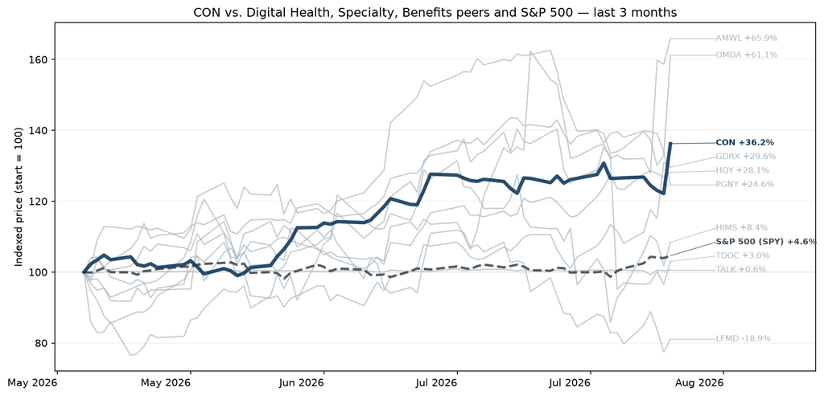

#### Earnings Call Summary

Concentra Group Holdings reported Q2 2026 revenue of $606 million, representing 10% year-over-year growth (8% excluding Pivot). Total occupational health center patient visits rose 2.6% to over 56,000 per day, with work comp visits up 3.7% and employer services up 1.8%, driven by a resilient blue-collar labor market and market share gains.

#### At a Glance

- **Concentra Strong Beats Q2 Expectations:** Concentra Group Holdings reported Q2 2026 adjusted EPS of $0.51, beating the estimated $0.421, while revenue reached $606.03 million against expectations of $591.99 million.
- **Patient Traffic and Revenue Expand:** The company delivered strong occupational health center metrics, with daily patient visits growing 2.6% to 56,421 and average revenue per visit increasing 4.6% to $152.67 compared to the prior year.
- **Full-Year Guidance Revised Upward:** Management raised its full-year 2026 revenue guidance to a range of $2.325 billion to $2.375 billion and adjusted EBITDA expectations to between $485 million and $495 million due to sustained operational momentum.
- **Strategic Leadership Succession Announced:** Concentra announced that long-time CEO Keith Newton will transition to Executive Chairman effective November 1, 2026, with current President and CFO Matt DiCanio succeeding him as the next CEO.
- **Leverage Milestone Triggers Interest Savings:** The company reduced its net leverage ratio ahead of schedule to 2.99x, triggering a favorable 25 basis point reduction in its credit agreement interest rate spread.

#### Key Moments from the Call

- **1m 21s — CEO Succession Plan Announced:** CEO Keith Newton will transition to Executive Chairman on November 1st, 2026, after over a decade in the role. Matt DiCanio, current President and CFO, will succeed him as President and CEO, signaling continuity in the company's long-term growth strategy.
- **9m 58s — Onsite Health Clinics Segment Outperforms:** The Onsite Health Clinics segment posted 72.1% revenue growth (27.9% organic), driven by the successful integration of the Pivot acquisition and expanding advanced primary care services, capturing high employer demand for workplace healthcare.
- **15m 57s — Leverage Target Reached Ahead of Schedule:** Net leverage dropped below 3.0x in Q2, hitting management's year-end goal early due to robust cash generation. This reduction triggers an automatic 25 basis point reduction in interest rate spreads on its term loan B, lowering forward interest expenses.
- **18m 11s — Full-Year 2026 Guidance Raised:** Management raised full-year 2026 guidance across revenue, Adjusted EBITDA, and free cash flow. This positive revision reflects strong year-to-date visit and rate growth, operational cost efficiencies, and market share gains, providing a strong positive signal to investors.

### Doximity (DOCS) +5.5%

**Reported:** August 6, 2026 · [Google Finance earnings page](https://www.google.com/finance/quote/DOCS:NYSE?tab=earnings&hl=en)

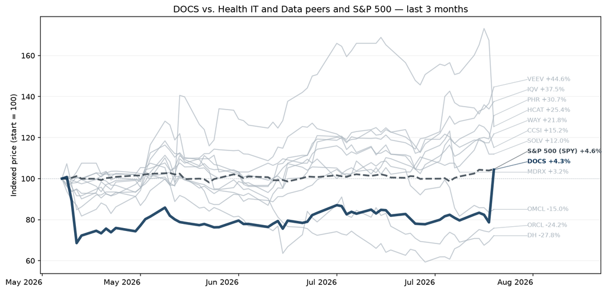

#### Earnings Call Summary

Doximity reported Q1 2027 revenue of $157M, up 7% year-over-year, and an adjusted EBITDA of $75M (48% margin), beating the high end of guidance by 3% and 8% respectively. This performance was driven by a re-acceleration across pharma and hospital clients, along with robust engagement from its largest subscription customers.

#### Key Moments from the Call

- **3m 45s — Independent Clinical AI Validation:** Doximity Ask outperformed major competitors like Anthropic's Fable 5 in the independent NOHARM study, validating the company's clinical accuracy and enhancing its competitive position with hospital AI steering committees.
- **8m 41s — AI Search Commercial Pipeline:** While no revenue was recognized from AI Search in Q1, the product is driving significant client engagement and unlocking innovation budgets. The majority of contracted AI Search revenue is expected to hit in Q3.
- **10m 32s — Gross Margin Compression from AI Compute:** Non-GAAP gross margin declined to 88% from 91% last year due to intentional increases in AI compute spend to support surging clinician usage, which will continue throughout fiscal 2027.
- **12m 30s — Full-Year Guidance Increase:** Management raised full-year fiscal 2027 revenue guidance by $6M to $671M-$681M, reflecting a more stable pharma budget environment, increased customer interaction velocity, and a growing commercial AI pipeline following the rollout of AI Search.

### Privia Health Group (PRVA) -2.6%

**Reported:** August 6, 2026 · [Google Finance earnings page](https://www.google.com/finance/quote/PRVA:NASDAQ?tab=earnings&hl=en)

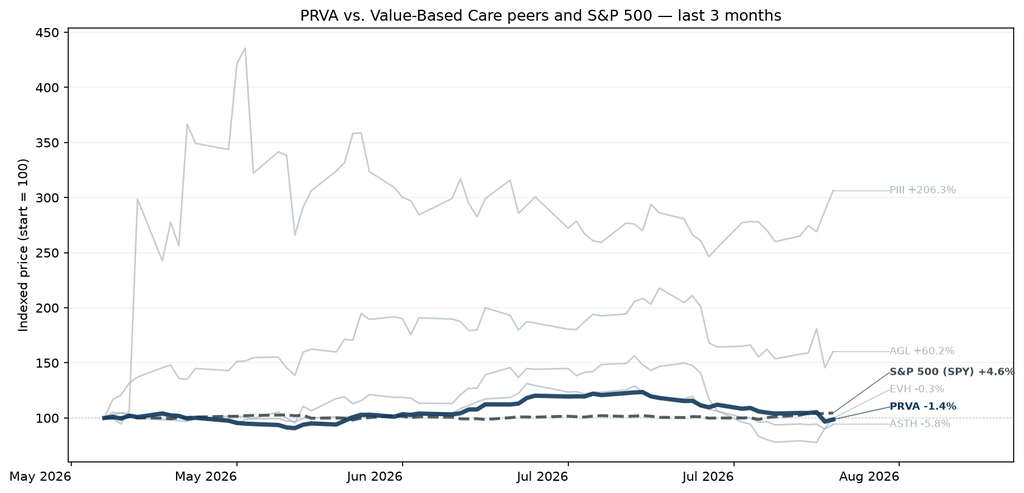

#### Earnings Call Summary

Privia Health achieved Q2 2026 practice collections growth of 12.4% year-over-year to $970 million, driven by a 10.1% increase in implemented providers and a 19.2% increase in value-based attributed lives. Adjusted EBITDA rose 29% to $37.4 million, reflecting 28.3% of care margin, expanding the EBITDA margin by 310 basis points due to operational leverage.

#### At a Glance

- **Top-Line Revenue Beats While EPS Misses Estimates:** Privia Health Group reported Q2 2026 revenue of $632.63 million, topping expectations of $600,761,020, but its reported adjusted EPS of $0.07 missed the consensus estimate of $0.244.
- **Strong Operational KPIs and Network Scaling:** The company's implemented provider base scaled up by 10.1% year-over-year to 5,644, while value-based care attributed lives jumped 19.2% to 1.64 million.
- **Management Raises Full-Year 2026 Guidance:** Following strong first-half momentum, management raised its full-year GAAP revenue guidance toward the high end of its prior $2.35 billion to $2.45 billion range.
- **Diversified Streams Fuel Local Utilization Health:** Fee-for-service patient care revenue rose 24.5% year-over-year to $412.6 million, capitated revenue grew 26.0% to $95.2 million, and care management fees increased 22.5% to $20.7 million.
- **Shares Drop on Cautious Growth Factors:** Despite the revenue beat and upgraded outlook, Privia Health shares fell roughly 5.2% to 11.3% as investors reacted to slower implied growth for the second half and potential timing delays in Medicare Shared Savings Program cash flows.
- **Margin Improvement Driven by Platform Leverage:** Adjusted EBITDA rose 29% year-over-year to $37.4 million, expanding its margin by 310 basis points to 28.3% of care margin as the company works toward its long-term 30% to 35% target.

#### Key Moments from the Call

- **7m 41s — Full-Year 2026 Guidance Increase:** Privia Health raised its 2026 full-year expectations for attributed lives above its prior guidance bracket, and moved practice collections, GAAP revenue, care margin, and adjusted EBITDA forecasts toward the upper ends of their ranges due to a strong first half.
- **11m 18s — EBITDA Margin Target Confidence:** Management expressed strong confidence in reaching the high end of its long-term 30% to 35% adjusted EBITDA margin as a percentage of care margin over the next few years, fueled by market maturity and ongoing deployments of corporate and clinical AI tools.
- **12m 30s — Conservative Second-Half Revenue Projections:** Analysts highlighted that the updated guidance implies a deceleration from 13% practice collections growth in the first half to 3% in the second half. Management characterized this as routine mid-year prudence rather than operational or market-driven utilization headwinds.
- **19m 7s — Integration of Evolent and IMS:** The company reported seamless operational integration of its prior-year acquisitions, Evolent's Care Partners and Arizona-based IMS. These assets are successfully expanding Privia's total addressable market through a dual-pronged go-to-market structure consisting of full medical groups and an ACO-only network model.

### Progyny (PGNY) +18.5%

**Reported:** August 6, 2026 · [Google Finance earnings page](https://www.google.com/finance/quote/PGNY:NASDAQ?tab=earnings&hl=en)

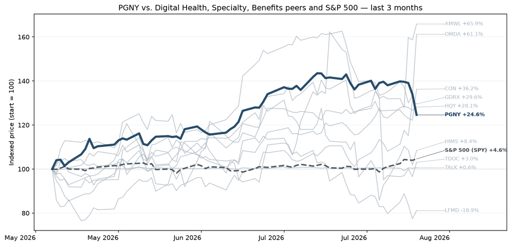

#### Earnings Call Summary

Progyny reported a strong Q2 2026, delivering record quarterly revenue of $350.51M, a 5.3% reported increase (11% excluding a transitioned client). Gross margin expanded 180 basis points, and adjusted EBITDA margin reached 17.2% on a trailing 12-month basis. The company maintains strong cash generation, exceeding $50M in operating cash flow for four of the last five quarters.

#### Key Moments from the Call

- **5m 53s — Accelerated Selling Season Secures 1M Lives Target:** Investors will be pleased by early commitments and de-risked client renewals pacing ahead of historical timelines. Driven by employers seeking cost-containment options against a 10%+ inflation environment, Progyny secured early jumbo wins and conversions, reinforcing high confidence in hitting its 1 million new lives target.
- **14m 19s — Robust Share Buybacks Support EPS Flexibility:** Progyny pleased shareholders by leveraging its consistent $200M+ trailing operating cash flow to fuel an aggressive buyback program. Total share repurchases since November have successfully reduced outstanding shares by 12.5%, providing a solid mechanism to enhance shareholder value alongside ongoing internal investments.
- **15m 17s — Pronounced Summer Seasonality Triggers Guidance Re-calibration:** Investors may feel cautious as management highlighted a more pronounced summer slowdown in member engagement. Though September scheduling indicates a return to normal baseline trends, the near-term softness prompted a narrowing of full-year revenue guidance to a 5.5% to 7.5% growth range, reflecting stable but conservative utilization expectations.
- **31m 48s — Favorable Shift Toward Competitive Brownfield Conversions:** Analysts heavily focused on market demand trends. Management revealed a significant shift toward "brownfield" wins, capturing market share directly from carrier and venture-backed solutions. Employers facing escalating healthcare and GLP-1 costs are actively seeking out Progyny due to its transparent ROI and proven total cost-containment track record.

### Clover Health (CLOV) +52.6%

**Reported:** August 5, 2026 · [Google Finance earnings page](https://www.google.com/finance/quote/CLOV:NASDAQ?tab=earnings&hl=en)

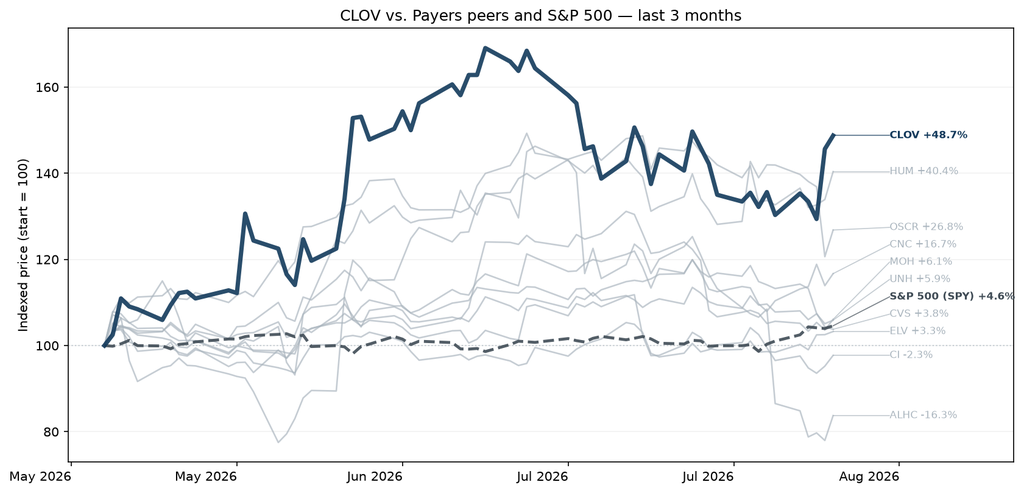

#### Earnings Call Summary

Clover Health reported strong performance for the first half of 2026, delivering 48% year-over-year Medicare Advantage membership growth and increasing GAAP net income by $67 million. Total revenue for the first half increased by over $550 million year-over-year to $1.5 billion, while consolidated gross profit grew by $104 million with operating leverage expanding by over 200 basis points.

#### At a Glance

- **Clover Health Meets EPS, Beats Revenue:** Clover Health reported an Adjusted EPS of $0.05, matching the analyst estimate, while total revenue reached $743,167,000, beating the expected $732,669,000.
- **Strong Medicare Advantage Membership Growth:** The company's core KPI, Medicare Advantage membership, surged 48% year-over-year to 157,309 average members, while its benefit-expense ratio improved to 87.6% from 88.4% in Q2 2025.
- **Full-Year Guidance Lifted Broadly:** Management raised its full-year 2026 revenue guidance midpoint to $2.96 billion alongside an upward adjustment to its Adjusted EBITDA outlook to $77.5 million at the midpoint.
- **AI Clinical Software Accelerates Profitability:** Operational improvements were largely driven by the scaling of the Clover Assistant platform, which enhances point-of-care clinical decisions and accelerates cohort maturation.
- **Market Reacts Positively After Hours:** Following the strong revenue beat and raised guidance, Clover Health's stock price jumped 10.39% in after-hours trading.

#### Key Moments from the Call

- **14m 27s — Full-Year 2026 Guidance Increased Across All Metrics:** Clover Health raised its full-year 2026 outlook following a strong first half, projecting full-year GAAP net income profitability of $20 million to $35 million and adjusted EBITDA of $70 million to $85 million, signaling greater confidence that recent member growth is successfully converting into expected long-term earnings.
- **17m 40s — Medicare Advantage Cohort Maturation Confirms Margin Improvement:** Management highlighted that historical member cohorts show a $70 PMPM gross profit step-up from year one to year two. This maturation curve is tracking as expected for the large 2025 cohort, validating the underlying earnings power and margin expansion potential of their full-risk care model heading into 2027.
- **20m 18s — Strategic Expansion of Back-Office AI Operations:** CEO Andrew Toy announced plans to quickly deploy AI into back-office insurance operations, including claims processing speed and accuracy. This administrative optimization aims to compound future margin opportunities and lower overhead, complementing the clinical benefits already realized through the flagship Clover Assistant platform.
- **27m 47s — Bids Factor in Continued Competitor Market Disruptions:** During the Q&A session, management disclosed that their 2027 Medicare Advantage bids accounted for continued market disruption and market exits by national and local competitors in core New Jersey and Georgia regions, allowing Clover to maintain a highly competitive and profitable growth posture.

### Addus HomeCare (ADUS) +20.2%

**Reported:** August 4, 2026 · [Google Finance earnings page](https://www.google.com/finance/quote/ADUS:NASDAQ?tab=earnings&hl=en)

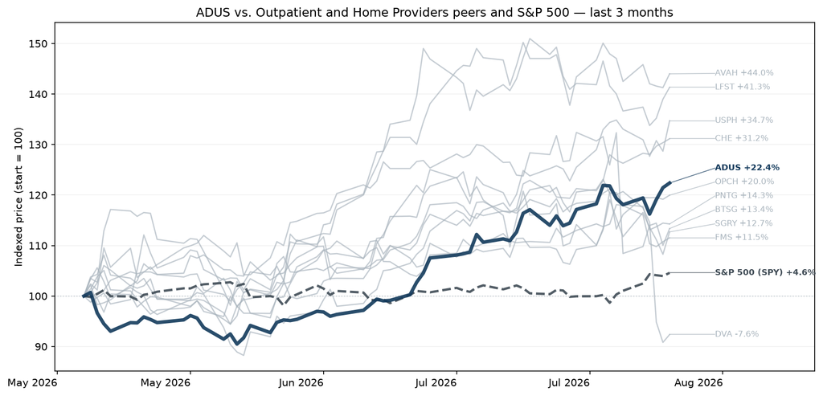

#### Earnings Call Summary

Addus HomeCare reported Q2 2026 revenue of $377.4 million, an 8% increase year-over-year from $349.4 million. Adjusted EPS grew 16.1% to $1.73, and adjusted EBITDA increased 11.9% to $49.2 million. Operating cash flow grew significantly to $40 million, enabling debt reduction to $64.3 million.

#### Key Moments from the Call

- **9m 26s — Medicare Cap Headwind in Hospice:** Investors may be concerned by a $3 million Medicare cap accrual penalty that impacted hospice margins this quarter. Management implements mitigation strategies and expects no further cap exposure for the remainder of 2026, targeting potential cost recovery before the cap year concludes.
- **21m 42s — Caregiver App Accelerated Texas Fill Rates:** The rollout of the new caregiver app has exceeded expectations in Texas, driving consolidated fill rates to 84%-85%. This digital tool has also contributed to a decline in caregiver turnover, helping alleviate the industry's primary constraint of labor supply to capture organic demand.
- **23m 27s — Full-Year Margin Guidance Rises Within Range:** Strong Q2 financial execution and G&A leverage positioned Addus to project full-year adjusted EBITDA margins toward the upper end of its 12% to 13% range. This operational efficiency gives investors greater confidence in bottom-line execution despite regional wage inflation pressures.
- **28m 59s — Scalable M&A Pipeline and Outlook:** Easing macro anxieties regarding regulatory Medicaid rule changes has motivated independent owners, driving an uptick in personal care pipeline opportunities. Combined with optimism surrounding the proposed 2027 home health payment rule, Addus is actively evaluating scaled platform acquisitions using its low leverage profile.

### Agilon Health (AGL) +76.1%

**Reported:** August 5, 2026 · [Google Finance earnings page](https://www.google.com/finance/quote/AGL:NYSE?tab=earnings&hl=en)

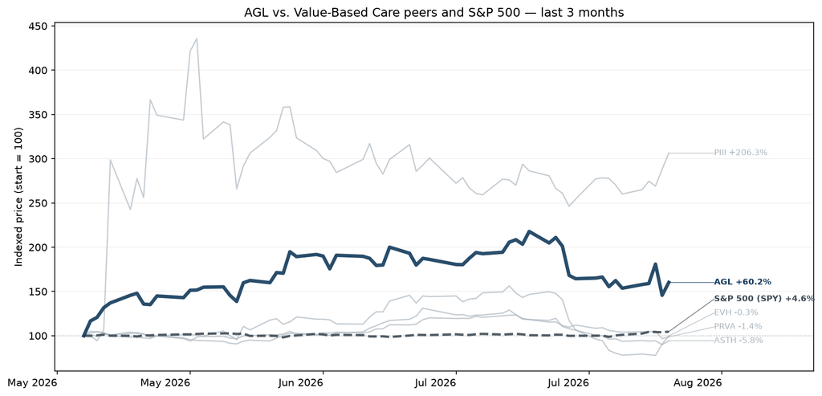

#### Earnings Call Summary

CEO Tim O'Rourke and CFO Jeff Schwaneke highlighted that agilon health exceeded Q2 2026 guidance across key financial metrics and raised its full-year 2026 outlook. The performance was driven by Q2 strength, moderating medical cost trends first seen in Q1, and a stronger-than-expected burden of illness program performance.

#### At a Glance

- **Agilon Health Beats Q2 Estimates:** Agilon Health reported a substantial bottom-line surprise with an Adjusted EPS of $1.04 compared to the estimated $0.272, alongside revenues of $1.49 billion that surpassed the $1.45 billion estimate.
- **Profits Swing High on KPIs:** The company's key performance metrics showed a powerful turnaround, with medical margin swinging to a positive $197 million from negative $53 million a year ago, and Adjusted EBITDA reaching $70 million.
- **Management Hikes Full-Year Guidance:** Capitalizing on strong performance, agilon health raised its full-year 2026 revenue guidance midpoint to $5.82 billion and pushed its expected full-year Adjusted EBITDA up to approximately $85 million.
- **Membership Shrinks for Strategic Profitability:** Total platform membership fell 10% year-over-year to 549,000, representing an intentional and disciplined contracting strategy to exit certain markets and prioritize long-term profitability.
- **Stock Rallies Following Core Turnaround:** Driven by the large earnings beat and enhanced full-year outlook, agilon health's stock reacted strongly, closing regular trading up over 13% after the release.

#### Key Moments from the Call

- **3m 30s — Full-Year 2026 Guidance Increase:** Agilon health raised its full-year 2026 guidance to $5.8B revenue, $485M medical margin, and $85M adjusted EBITDA. This positive revision will please investors as it reflects structural medical cost moderation and higher risk adjustment revenue, proving that the company's operational discipline and data pipelines are driving material financial improvements.
- **14m 25s — Significant Risk Score Uplift:** Net risk adjustment revenue estimates increased to 3% year-over-year, doubling the prior 1.5% estimate. This positive development will please investors because it demonstrates the clear success of agilon's clinical programs and enhanced data pipeline, providing better-than-expected revenue flow-through and earlier operational visibility.
- **15m 28s — Favorable Medical Cost Trend Developments:** Estimated full-year 2025 cost trends dropped to 5.8% from 6.2%, and Q1 2026 trends improved to the low 6% range. This structural improvement will reassure investors that macro utilization pressures are easing and that agilon's clinical pathways are successfully reducing unnecessary hospitalizations and ER visits.
- **23m 17s — Payer Contracting and 2027 Outlook:** Management touched 80% of contracts last year and has 50% open for renegotiation this year, aiming to minimize Part D exposure below the current 15% level. This strategic shift will comfort investors by showcasing continuous portfolio refinement to lock in profitability ahead of 2027 market changes.

### Ardent Health Partners (ARDT) +14.2%

**Reported:** August 5, 2026 · [Google Finance earnings page](https://www.google.com/finance/quote/ARDT:NYSE?tab=earnings&hl=en)

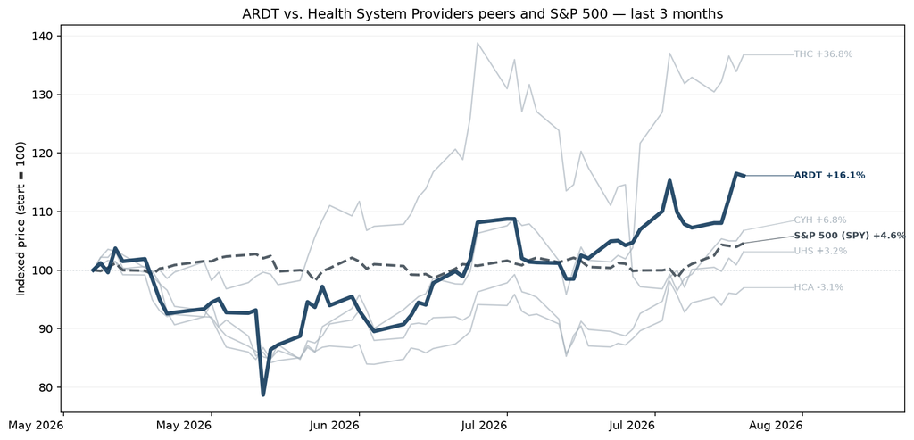

#### Earnings Call Summary

Management implemented a multi-year operational transformation program named IMPACT, increasing the 2026 savings target from $55M to at least $70M. This expansion was driven by structural changes executed in Q2 to reduce managerial layers across corporate and field locations, which is expected to yield $15M-$20M in additional savings this year.

#### At a Glance

- **Ardent Health Misses EPS Estimates:** Ardent Health reported Q2 2026 adjusted EPS of $0.12, missing the estimated $0.19, while quarterly revenue came in at $1.62 billion, which beat the estimated $1.59 billion.
- **Mixed Volume Performance in KPIs:** Adjusted admissions grew by 2.5% year-over-year, but actual admissions fell 1.0% and total surgeries declined 2.9% due to weakness in April and May before rebounding in June.
- **Full-Year Financial Guidance Maintained:** Management reaffirmed its full-year 2026 outlook, projecting total revenue between $6.4 billion and $6.7 billion and adjusted EBITDA between $485 million and $535 million.
- **Robust Operating Cash Flow Surge:** Despite profitability pressures and volume headwinds, operating cash flow jumped 67.4% year-over-year to reach $197 million for the quarter.
- **Positive Stock Performance Following Results:** Shares of Ardent Health rose over 7.8% following the earnings release as investors prioritized strong cash flow generation and tighter cost controls over the profit miss.
- **IMPACT Savings Target Increased Higher:** The company raised its full-year 2026 IMPACT program efficiency savings target to at least $70 million, up from the previous projection of $55 million.

#### Key Moments from the Call

- **5m 41s — Strategic Outpatient Payer Contract Win:** The execution of a data-driven contract renewal added an unexpected $5M-$10M to this year's EBITDA. Management highlighted that this single market renewal validates an ongoing portfolio-wide strategy to recontract underpriced outpatient rates, giving investors a clear catalyst for future structural revenue yield improvements.
- **7m 41s — IMPACT Program Target Upgraded to $70M:** To counteract challenging volume dynamics, management aggressively pulled forward internal cost initiatives and streamlined corporate and field managerial structures. This decision increased the 2026 cost savings target to at least $70M, demonstrating strong operational flexibility and reassuring investors focused on near-term margin protection.
- **15m 54s — Lower Revenue Outlook but Confirmed EBITDA Guidance:** Ardent Health now biases full-year revenue toward the low end of its $6.4B-$6.7B range due to early Q2 volume softness. However, management pleased investors by maintaining its full-year adjusted EBITDA guidance of $485M-$535M, utilizing immediate cost actions and a key payer renewal to fully offset the $25M volume headwind.
- **22m 3s — Inpatient to Outpatient Surgical Mix Shift:** Analysts probed a steep drop in inpatient surgeries. Management explained this was driven primarily by procedures moving off the inpatient-only list, and reassured investors that the net financial impact of this mix shift was extremely modest at just $1M-$2M for the quarter.

### Pennant Group (PNTG) +8.6%

**Reported:** August 6, 2026 · [Google Finance earnings page](https://www.google.com/finance/quote/PNTG:NASDAQ?tab=earnings&hl=en)

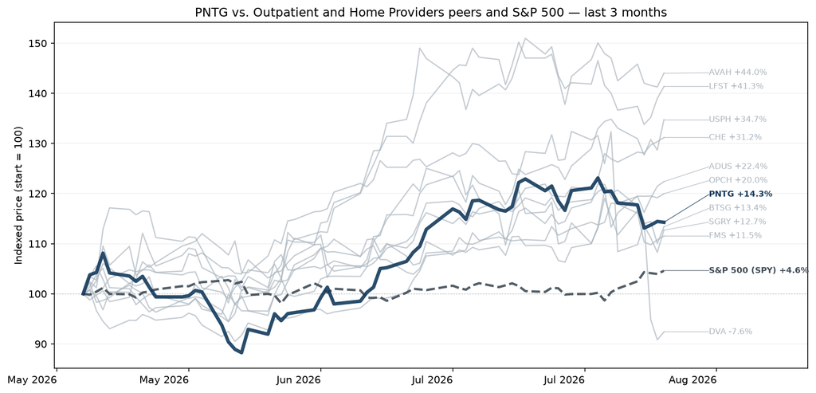

#### Earnings Call Summary

The Pennant Group reported strong Q2 2026 revenue of $298.0 million, up 35.8% year-over-year, and adjusted EPS of $0.36, up 33.3%, both beating market consensus. Growth was driven by solid organic trends and the successful transition of its largest historical acquisition in the Southeast.

#### Key Moments from the Call

- **4m 54s — Favorable Proposed Home Health Rule:** The 2027 proposed home health rule indicates a positive reversal in the regulatory rate cycle with a modeled 1.7% base rate increase for Pennant, relieving multi-year reimbursement pressures and improving long-term outlook visibility.
- **6m 50s — Full Year 2026 Guidance Raised:** Management increased full year revenue and EPS guidance above initial expectations, signaling strong operational momentum and faster-than-planned financial integration of their large Southeast acquisition, which will please investors looking for sustained growth.
- **11m 30s — Southeast Integration Outperformance:** Integration of the massive Amedisys asset package in the Southeast is trending ahead of internal expectations on volume retention and financial margins, reducing execution risk during its peak transition waves through October.
- **45m 6s — CapEx Drag on Near-Term Cash Flow:** Elevated CapEx driven by turnaround efforts at distressed, newly acquired senior living buildings, alongside increased debt from the Hartford investment, highlights an ongoing capital allocation trade-off between growth funding and near-term leverage reduction.

### QuidelOrtho (QDEL) +13.8%

**Reported:** August 6, 2026 · [Google Finance earnings page](https://www.google.com/finance/quote/QDEL:NASDAQ?tab=earnings&hl=en)

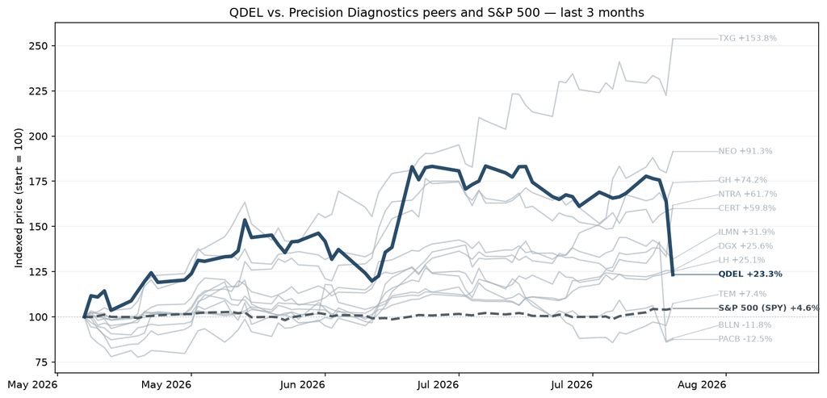

#### Earnings Call Summary

QuidelOrtho reported Q2 2026 total revenue growth of 2% on a constant currency basis. Growth reached 6% excluding China, driven by broad-based core strength including 9% non-China labs revenue growth and a 9% expansion in TRIAGE. Adjusted EBITDA surged 21% to $129 million, expanding margins by 310 basis points to 20%.

#### At a Glance

- **QuidelOrtho Surpasses Q2 Top-Line Estimates:** QuidelOrtho reported revenue of $630.9 million, beating the estimated $618.83 million, while reported adjusted EPS came in at $0.13, significantly ahead of the estimated loss of $0.05 per share.
- **Core Regions Performance Offsets China Weakness:** Excluding China, total revenue grew 6% constant currency with Labs segment revenue up 9% and TRIAGE revenue expanding 9%, although a 23% year-over-year revenue drop in China due to policy changes pressured overall growth.
- **Management Drastically Lowers Full-Year Outlook:** QuidelOrtho slashed its full-year 2026 revenue guidance to a range of $2.52 billion to $2.60 billion from the prior $2.70 billion to $2.75 billion, alongside withdrawing its free cash flow guidance due to respiratory market and China uncertainties.
- **Adjusted EBITDA Margins Expand From Cost-Savings:** Adjusted EBITDA grew 21% year over year to $129.3 million, driving a 310-basis-point margin expansion to 20.5% thanks to active internal cost-cutting initiatives.
- **Market Reaction Sinks Share Price Post-Earnings:** Despite the second-quarter earnings beat, QuidelOrtho shares plummeted over 21% as investor sentiment turned sharply negative following the massive full-year guidance cuts.

#### Key Moments from the Call

- **3m 28s — Strong EBITDA Expansion Despite China Headwinds:** Investors will be pleased by a 21% increase in adjusted EBITDA to $129 million and 310 basis points of EBITDA margin expansion. This highlights resilient operational productivity, cost discipline, and 6% revenue growth outside of China, showcasing underlying business health despite regional market volatility.
- **8m 8s — Full Year 2026 Guidance Downgrade:** QuidelOrtho disappointed investors by lowering its full year revenue, adjusted EBITDA, and EPS guidance, while withdrawing free cash flow guidance entirely. This retreat stems from prolonged buying friction and policy uncertainty in China, combined with conservative, below-average modeling for the upcoming respiratory season due to low early positivity rates.
- **12m 32s — New CFO Outlines Balance Sheet Priorities:** Newly appointed CFO Micah Young focused heavily on stabilizing the company's financial profile. Addressing a net debt leverage of 4.3x adjusted EBITDA, he prioritized working capital improvements, optimizing instrument investment returns, and scaling back capital expenditures to accelerate debt reduction and improve cash conversion efficiency.
- **19m 22s — Addressing Point-of-Care Business Sale Rumors:** During the Q&A session, CEO Brian Blaser refused to comment directly on media speculation regarding a potential sale of the company's point-of-care business. However, he noted that the board regularly evaluates portfolio optimization opportunities to enhance shareholder returns, keeping investors attentive to future strategic shifts.

### Certara (CERT) +30.0%

**Reported:** August 4, 2026 · [Google Finance earnings page](https://www.google.com/finance/quote/CERT:NASDAQ?tab=earnings&hl=en)

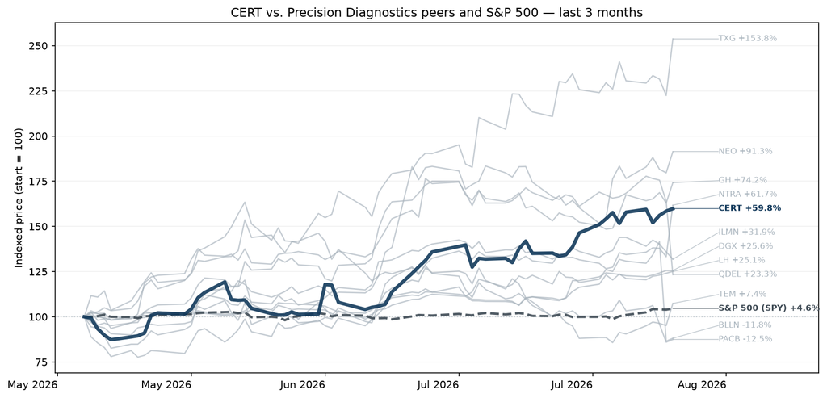

#### Earnings Call Summary

Certara reported Q2 2026 total revenue of $93.3M, missing the estimated $98.1M and representing modest 1% YoY growth. Software revenue rose 4% to $48.8M, representing 53% of the business, while services revenue declined 3% to $44.5M following the Regulatory and Medical Writing business carve-out.

#### Key Moments from the Call

- **14m 0s — Revenue and EPS Miss Market Estimates:** Certara's Q2 2026 revenue of $93.3M and adjusted EPS of $0.08 came in below analyst expectations of $98.1M and $0.091. This softer financial showing was heavily impacted by the divestiture of its Regulatory and Medical Writing business, which caused a 3% decline in services segment revenue.
- **19m 4s — Full-Year Margin and EPS Guidance Cut:** Management lowered its 2026 adjusted EBITDA margin guidance midpoint by 100 basis points to 29%–31% and reduced full-year adjusted EPS guidance to $0.31–$0.36. While the business unit underlying trends remain intact, the cuts reflect lingering unallocated infrastructure overhead following the May asset sale.
- **21m 9s — Strategic Commercial Transformation and New Leadership:** Investors will be pleased by a 27% YoY pipeline expansion following a pivot back to specialist, scientist-led commercial teams. The operational course correction is being solidified by the appointment of Julien Perrier as Chief Commercial Officer to aggressively monetize cloud-based pharmacometrics and international markets.
- **39m 25s — Increased Cost Savings Framework:** To defend margins against structural headwinds, Certara boosted its annualized run-rate cost savings target to $13 million, up from the previously outlined $10 million plan. The enhanced savings will be driven by the 5% reduction in force implemented at the start of Q3.

### Omada Health (OMDA) +59.7%

**Reported:** August 6, 2026 · [Google Finance earnings page](https://www.google.com/finance/quote/OMDA:NASDAQ?tab=earnings&hl=en)

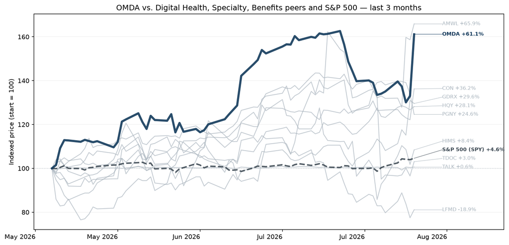

#### Earnings Call Summary

Co-founder and CEO Sean Duffy announced he will pass leadership to President Wei-Li Shao on January 1, 2027, transitioning to Executive Chair to focus on long-term strategy and partnerships after 15 years at the helm.

#### At a Glance

- **Omada Health Beats Q2 Estimates:** Omada Health reported an adjusted EPS of $0.08, beating the estimated $0.061, and generated revenue of $87.84 million, outperforming the projected $80.06 million.
- **Strong Growth in Core KPIs:** Total members increased 45% year-over-year to approximately 1.1 million, while trailing twelve-month revenue per total member edged up to $284.
- **Full Year 2026 Guidance Raised:** The company raised its full-year 2026 revenue guidance to between $334 million and $340 million, alongside an updated adjusted EBITDA projection of $21 million to $27 million.
- **Upcoming CEO Leadership Transition Planned:** Co-founder Sean Duffy will transition to Executive Chair on January 1, 2027, with President Wei-Li Shao slated to succeed him as Chief Executive Officer.
- **Positive Market and Profitability Reaction:** Shares climbed over 5% in after-hours trading as the company secured its second consecutive quarter of GAAP profitability, netting $5 million.

#### Key Moments from the Call

- **1m 25s — CEO Succession Announced:** Co-founder Sean Duffy is handing the CEO role to President Wei-Li Shao effective January 1, 2027. This planned leadership transition positions the company to tackle its next expansion phase under a trusted commercial veteran.
- **5m 12s — Significant Gross Margin Expansion:** GAAP gross margin expanded by 700 basis points year-over-year to 73%, exceeding long-term targets. This structural profitability was driven by lower care delivery costs and deployment of AI efficiencies across operations.
- **18m 25s — Full-Year 2026 Guidance Raised:** Omada raised its full-year revenue and adjusted EBITDA guidance following significant Q2 beats, signaling strong fundamental momentum, even though year-over-year growth rates are expected to moderate in H2 due to traditional benefit-cycle seasonality.
- **28m 15s — Core Cardiometabolic Books Growth outpaces GLP-1s:** Diabetes and Hypertension program books grew over 50% year-over-year, outpacing overall revenue growth. Management highlighted that GLP-1 discussions act as a strategic pipeline bridge to cross-sell these higher-value, longer-duration programs.